# EIPAAB_data_summary

#### 10.7.6.1 Fig 5a

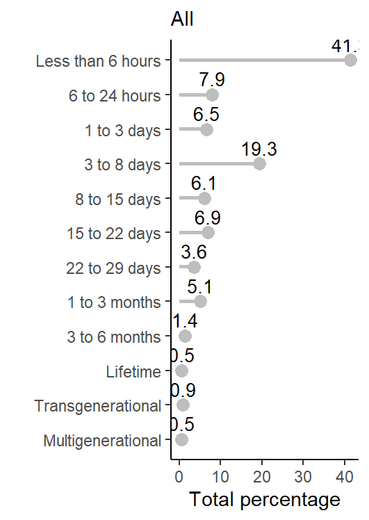

```r
exp_duration_all_fig
```

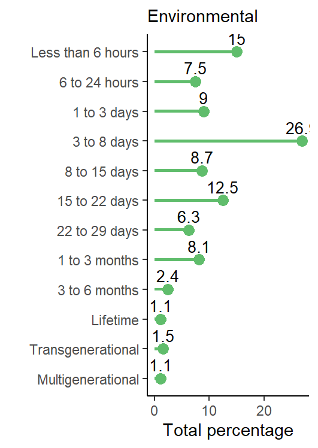

```r
exp_duration_env_fig
```

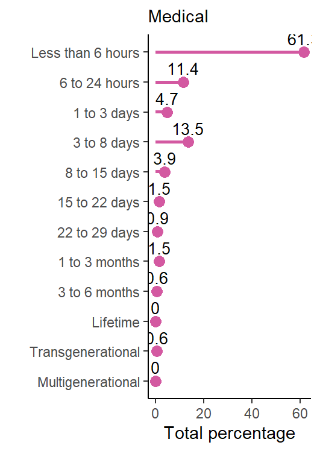

```r
exp_duration_med_fig
```

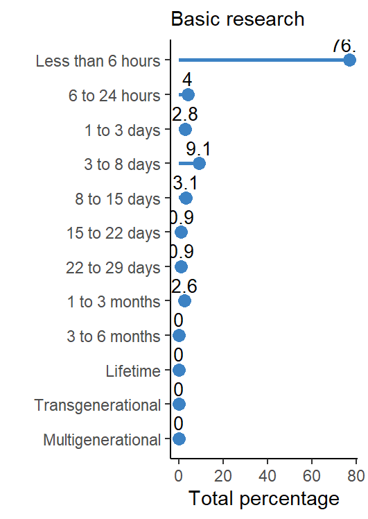

```r
exp_duration_base_fig
```

Save plots

```r
# setwd(figures_path) ggsave('comp_exp_duration_all_fig.pdf', plot =
# exp_duration_all_fig, width = 8.3/3, height = 11.7/3)
# ggsave('comp_exp_duration_env_fig.pdf', plot = exp_duration_env_fig, width =
# 8.3/3, height = 11.7/3) ggsave('comp_exp_duration_med_fig.pdf', plot =
# exp_duration_med_fig, width = 8.3/3, height = 11.7/3)
# ggsave('comp_exp_duration_base_fig.pdf', plot = exp_duration_base_fig, width
# = 8.3/3, height = 11.7/3)
```

### 10.7.7 Number of doses

Here I will look at the number of doses used. This was meassured as the total treatments (i.e. inculding control), so if we want to know the number of doses for the compound we need to subtract 1. I have done this below.

```r
n_doses_summary <- EIPAAB_database %>%
    dplyr::filter(!is.na(compound_treatment_levels)) %>%
    dplyr::mutate(n_doses = compound_treatment_levels - 1) %>%
    dplyr::group_by(n_doses) %>%
    dplyr::reframe(n = n()) %>%
    dplyr::mutate(total = sum(n), percent = round((n/total) * 100, 1), study_motivation = "All")

n_doses_summary %>%
    gt()
```

| n_doses | n | total | percent | study_motivation |
| --- | --- | --- | --- | --- |
| 1 | 449 | 1513 | 29.7 | All |
| 2 | 203 | 1513 | 13.4 | All |
| 3 | 377 | 1513 | 24.9 | All |
| 4 | 172 | 1513 | 11.4 | All |
| 5 | 163 | 1513 | 10.8 | All |
| 6 | 46 | 1513 | 3.0 | All |
| 7 | 50 | 1513 | 3.3 | All |
| 8 | 14 | 1513 | 0.9 | All |
| 9 | 11 | 1513 | 0.7 | All |
| 10 | 10 | 1513 | 0.7 | All |
| 11 | 10 | 1513 | 0.7 | All |
| 12 | 5 | 1513 | 0.3 | All |
| 13 | 2 | 1513 | 0.1 | All |
| 17 | 1 | 1513 | 0.1 | All |

Let’s see how many use more then 5

```r
n_doses_summary %>%
    dplyr::filter(n_doses > 5) %>%
    dplyr::summarise(over_5_percent = sum(percent)) %>%
    gt()
```

| over_5_percent |
| --- |
| 9.8 |

Looking by study motivation

```r
n_doses_motivation_summary <- EIPAAB_database %>%
    dplyr::filter(!is.na(compound_treatment_levels)) %>%
    dplyr::mutate(n_doses = compound_treatment_levels - 1) %>%
    dplyr::group_by(n_doses, study_motivation) %>%
    dplyr::summarise(n = n(), .groups = "drop") %>%
    tidyr::complete(n_doses, study_motivation, fill = list(n = 0)) %>%
    dplyr::group_by(study_motivation) %>%
    dplyr::mutate(total = sum(n)) %>%
    dplyr::ungroup() %>%
    dplyr::mutate(percent = round((n/total) * 100, 1))
```

#### 10.7.7.1 Fig 5b

Making a plot

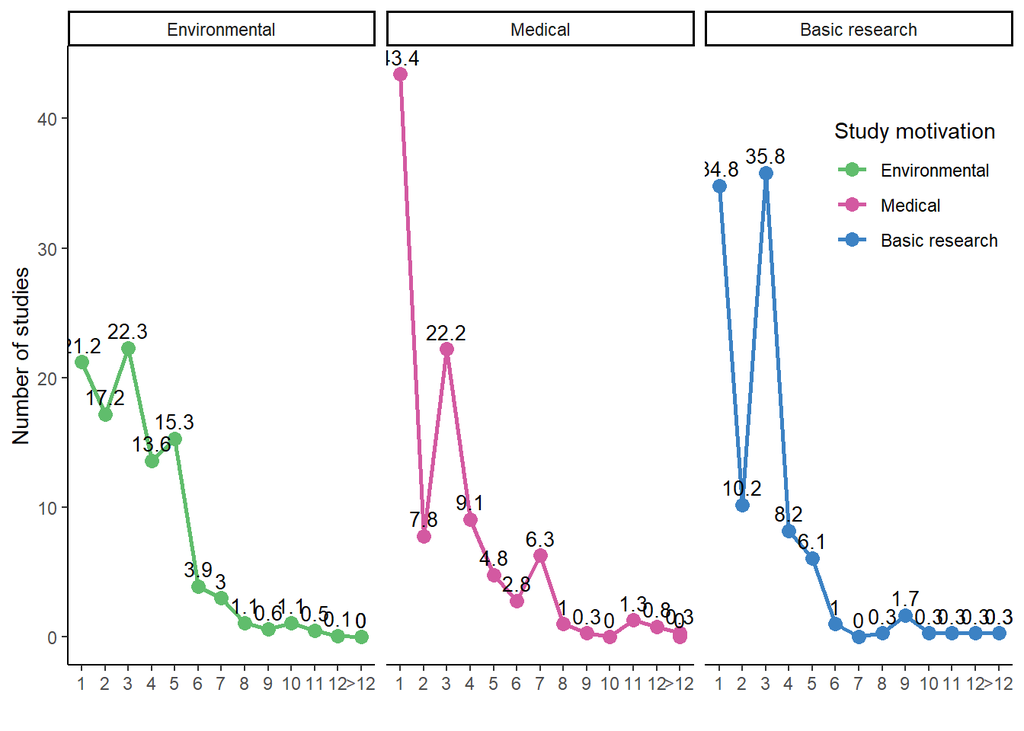

```r
dose_order <- c(1:12, ">12")

doses_fig <- n_doses_motivation_summary %>%
  dplyr::mutate(n_doses = as.character(if_else(n_doses>13, 13, n_doses)),
                n_doses = if_else(n_doses == "13", ">12", n_doses),
                n_doses = factor(n_doses, levels = dose_order)
                )%>%
  ggplot(aes(x=n_doses, y=percent, colour = study_motivation,
             fill = study_motivation, group = study_motivation)) +
  geom_point(position = position_dodge(width = 0.8), size = 3) +
  geom_line(size = 1) +
  geom_text(aes(label = percent), vjust=-0.6, size=3.5, color="black") +
  scale_colour_manual(values = motivation_colour_theme, name = "Study motivation") +
  scale_fill_manual(values = motivation_colour_theme, name = "Study motivation") +
  theme_classic() +
  facet_wrap(~study_motivation) +
  theme(
    legend.position = c(0.8, 0.9), # Positioning the legend in the top-left corner within the plot
    legend.justification = c(0, 1) # Ensuring the legend box aligns properly at the top-left corner
    ) +
   labs(
    x = "",
    y = "Number of studies"
  ) +
   theme()

doses_fig
```

Save the plot

```r
# setwd(figures_path) ggsave('comp_doses_fig.pdf', plot = doses_fig, width =
# 8.3, height = 11.7/3)
```

### 10.7.8 Concentrations

```r
nrow <- EIPAAB_database %>%
    nrow()

EIPAAB_database %>%
    dplyr::group_by(compound_min_dose_unit_std) %>%
    dplyr::reframe(n = n(), prop = n/nrow) %>%
    dplyr::arrange(desc(n)) %>%
    gt()
```

| compound_min_dose_unit_std | n | prop |
| --- | --- | --- |
| ug/L | 1076 | 0.618746406 |
| uM | 397 | 0.228292122 |
| NA | 228 | 0.131109833 |
| uM/L | 25 | 0.014376078 |
| ppm | 9 | 0.005175388 |
| uL/L | 2 | 0.001150086 |
| ug/g | 2 | 0.001150086 |

Summary of the minimum concentration used (where reported in mass to volume)

```r
EIPAAB_database <- EIPAAB_database %>%
    dplyr::mutate(range = compound_max_dose_std - compound_min_dose_std)
```

Dose summary by motivation

```r
EIPAAB_database %>%
    dplyr::filter(compound_min_dose_unit_std == "ug/L", compound_max_dose_unit_std ==
        "ug/L") %>%
    dplyr::mutate(range = compound_max_dose_std - compound_min_dose_std) %>%
    dplyr::group_by(study_motivation) %>%
    dplyr::reframe(median_min = median(compound_min_dose_std, na.rm = T), sd_min = sd(compound_min_dose_std,
        na.rm = T), min_min = min(compound_min_dose_std, na.rm = T), max_min = max(compound_min_dose_std,
        na.rm = T), median_max = median(compound_max_dose_std, na.rm = T), sd_max = sd(compound_max_dose_std,
        na.rm = T), min_max = min(compound_max_dose_std, na.rm = T), max_max = max(compound_max_dose_std,
        na.rm = T), median_range = median(range, na.rm = T), sd_range = sd(range,
        na.rm = T), min_range = min(range, na.rm = T), max_range = max(range, na.rm = T)) %>%
    gt()
```

| study_motivation | median_min | sd_min | min_min | max_min | median_max | sd_max | min_max | max_max | median_range | sd_range | min_range | max_range |
| --- | --- | --- | --- | --- | --- | --- | --- | --- | --- | --- | --- | --- |
| Environmental | 0.995 | 25255.8 | 3.13e-06 | 5.0e+05 | 100 | 140651.2 | 0.001 | 1600000 | 51.69 | 135347.17 | -1e-05 | 1579600 |
| Medical | 1000.000 | 74500.7 | 5.00e-02 | 5.4e+05 | 5000 | 206906.9 | 0.050 | 1943000 | 0.00 | 196100.58 | 0e+00 | 1942030 |
| Basic research | 3000.000 | 5301683.4 | 1.00e-02 | 6.0e+07 | 10000 | 5299563.0 | 0.010 | 60000000 | 72.00 | 84083.83 | 0e+00 | 600000 |

#### 10.7.8.1 Fig 5c-1

A plot for minimum doses, its on the log axis because the distribution is highly skewed motivation_colour_theme

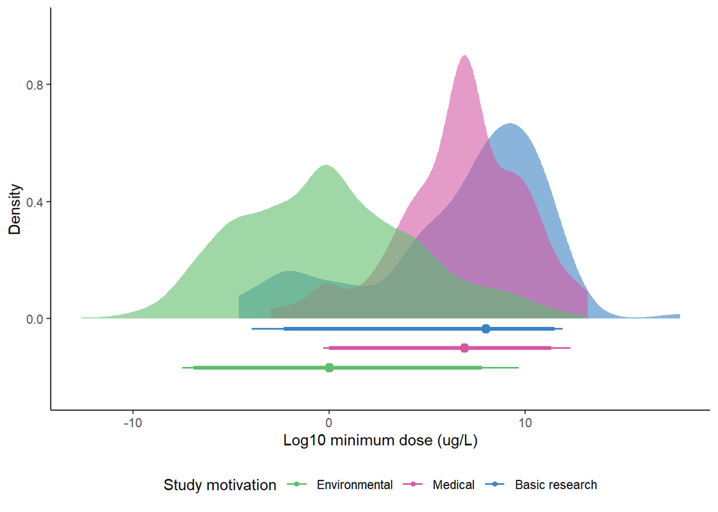

```r
motivation_colour_theme <- c("#60BD6C", "#D359A1", "#3C82C4")

min_conc_fig <- EIPAAB_database %>%
    dplyr::filter(compound_min_dose_unit_std == "ug/L") %>%
    ggplot(aes(x = log(compound_min_dose_std), fill = study_motivation, colour = study_motivation)) +
    stat_slab(alpha = 0.6, linewidth = 1.5, colour = NA) + stat_pointinterval(point_interval = "median_qi",
    position = position_dodge(width = 0.4, preserve = "single"), .width = c(0.89,
        0.95)) + scale_fill_manual(values = motivation_colour_theme, name = "Study motivation",
    guide = "none") + scale_colour_manual(values = motivation_colour_theme, name = "Study motivation") +
    theme_classic() + labs(x = "Log10 minimum dose (ug/L)", y = "Density") + theme(legend.position = "bottom")

min_conc_fig
```

Save the figure

```r
# setwd(figures_path) ggsave('comp_min_conc_fig.pdf', plot = min_conc_fig,
# width = 5, height = 6)
```

A summary table so we can see what the corresponding raw values are in the plot

```r
min_conc_summary <- EIPAAB_database %>%
    dplyr::filter(compound_min_dose_unit_std == "ug/L") %>%
    dplyr::group_by(study_motivation) %>%
    dplyr::summarise(median = median(log(compound_min_dose_std), na.rm = TRUE), lower_89 = quantile(log(compound_min_dose_std),
        probs = 0.11, na.rm = TRUE), upper_89 = quantile(log(compound_min_dose_std),
        probs = 0.89, na.rm = TRUE), lower_95 = quantile(log(compound_min_dose_std),
        probs = 0.05, na.rm = TRUE), upper_95 = quantile(log(compound_min_dose_std),
        probs = 0.95, na.rm = TRUE), .groups = "drop") %>%
    # Transform to a format suitable for ggplot annotation
pivot_longer(cols = -study_motivation, names_to = "stat", values_to = "value") %>%
    dplyr::mutate(vaule_raw = format(exp(value), scientific = FALSE))
```

#### 10.7.8.2 Fig 5c-2

A plot for maximum doses, its on the log axis because the distribution is highly skewed motivation_colour_theme

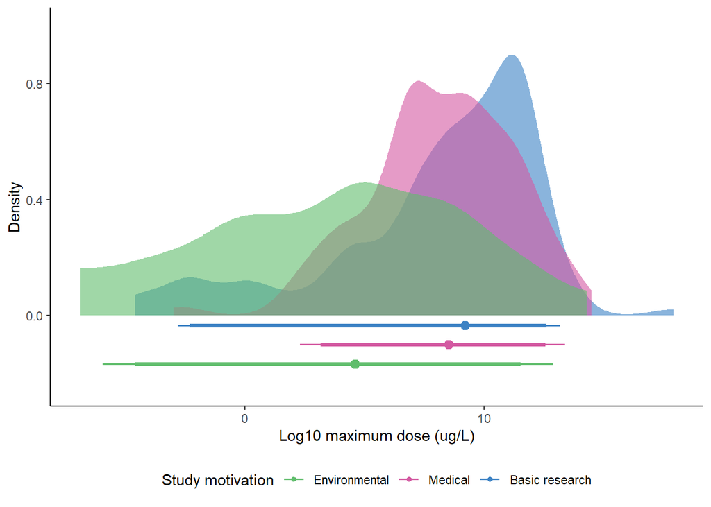

```r
motivation_colour_theme <- c("#60BD6C", "#D359A1", "#3C82C4")

max_conc_fig <- EIPAAB_database %>%
    dplyr::filter(compound_min_dose_unit_std == "ug/L") %>%
    ggplot(aes(x = log(compound_max_dose_std), fill = study_motivation, colour = study_motivation)) +
    stat_slab(alpha = 0.6, linewidth = 1.5, colour = NA) + stat_pointinterval(point_interval = "median_qi",
    position = position_dodge(width = 0.4, preserve = "single"), .width = c(0.89,
        0.95)) + scale_fill_manual(values = motivation_colour_theme, name = "Study motivation",
    guide = "none") + scale_colour_manual(values = motivation_colour_theme, name = "Study motivation") +
    theme_classic() + labs(x = "Log10 maximum dose (ug/L)", y = "Density") + theme(legend.position = "bottom")

max_conc_fig
```

Save the figure

```r
# setwd(figures_path) ggsave('comp_max_conc_fig.pdf', plot = max_conc_fig,
# width = 5, height = 6)
```

A summary table so we can see what the corresponding raw values are in the plot

```r
max_conc_summary <- EIPAAB_database %>%
    dplyr::filter(compound_min_dose_unit_std == "ug/L") %>%
    dplyr::group_by(study_motivation) %>%
    dplyr::summarise(median = median(log(compound_max_dose_std), na.rm = TRUE), lower_89 = quantile(log(compound_max_dose_std),
        probs = 0.11, na.rm = TRUE), upper_89 = quantile(log(compound_max_dose_std),
        probs = 0.89, na.rm = TRUE), lower_95 = quantile(log(compound_max_dose_std),
        probs = 0.05, na.rm = TRUE), upper_95 = quantile(log(compound_max_dose_std),
        probs = 0.95, na.rm = TRUE), .groups = "drop") %>%
    # Transform to a format suitable for ggplot annotation
pivot_longer(cols = -study_motivation, names_to = "stat", values_to = "value") %>%
    dplyr::mutate(vaule_raw = format(exp(value), scientific = FALSE))
```

#### 10.7.8.3 Fig 5c-3

A plot for the range of doses, its on the log axis because the distribution is highly skewed. This includes only studies that had more then one dose and reported concentration in a mass to volume metric.

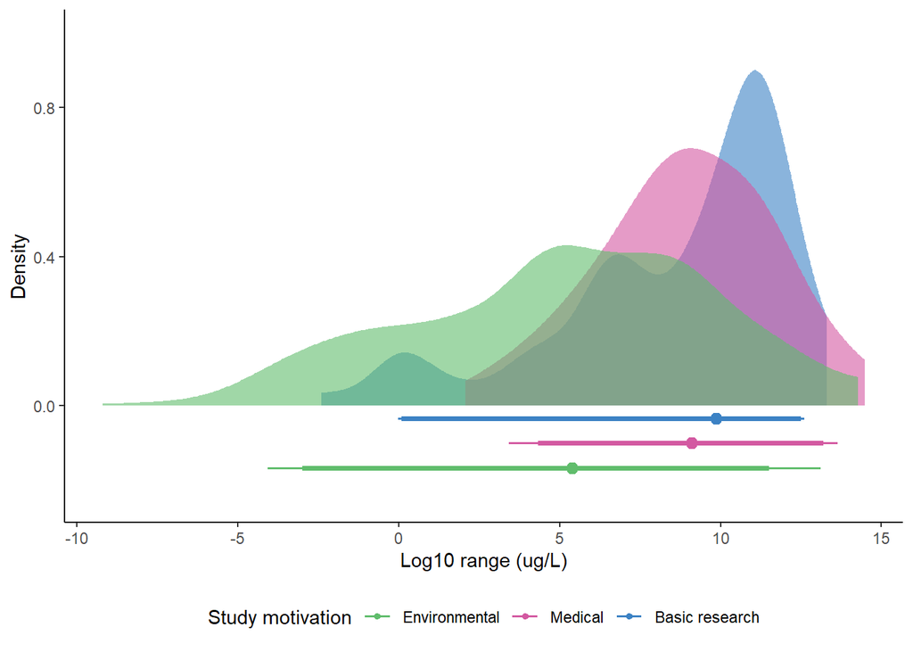

```r
motivation_colour_theme <- c("#60BD6C", "#D359A1", "#3C82C4")

range_conc_fig <- EIPAAB_database %>%
    dplyr::filter(compound_min_dose_unit_std == "ug/L") %>%
    dplyr::filter(range > 0) %>%
    ggplot(aes(x = log(range), fill = study_motivation, colour = study_motivation)) +
    stat_slab(alpha = 0.6, linewidth = 1.5, colour = NA) + stat_pointinterval(point_interval = "median_qi",
    position = position_dodge(width = 0.4, preserve = "single"), .width = c(0.89,
        0.95)) + scale_fill_manual(values = motivation_colour_theme, name = "Study motivation",
    guide = "none") + scale_colour_manual(values = motivation_colour_theme, name = "Study motivation") +
    theme_classic() + labs(x = "Log10 range (ug/L)", y = "Density") + theme(legend.position = "bottom")

range_conc_fig
```

Save the figure

```r
# setwd(figures_path) ggsave('comp_range_conc_fig.pdf', plot = range_conc_fig,
# width = 5, height = 6)
```

A summary table so we can see what the corresponding raw values are in the plot

```r
range_conc_summary <- EIPAAB_database %>%
    dplyr::filter(compound_min_dose_unit_std == "ug/L", range > 0) %>%
    dplyr::group_by(study_motivation) %>%
    summarise(median = median(log(range), na.rm = TRUE), lower_89 = quantile(log(range),
        probs = 0.055, na.rm = TRUE), upper_89 = quantile(log(range), probs = 0.945,
        na.rm = TRUE), lower_95 = quantile(log(range), probs = 0.025, na.rm = TRUE),
        upper_95 = quantile(log(range), probs = 0.975, na.rm = TRUE)) %>%
    # Transform to a format suitable for ggplot annotation
pivot_longer(cols = -study_motivation, names_to = "stat", values_to = "value") %>%
    dplyr::mutate(vaule_raw = format(exp(value), scientific = FALSE))
```

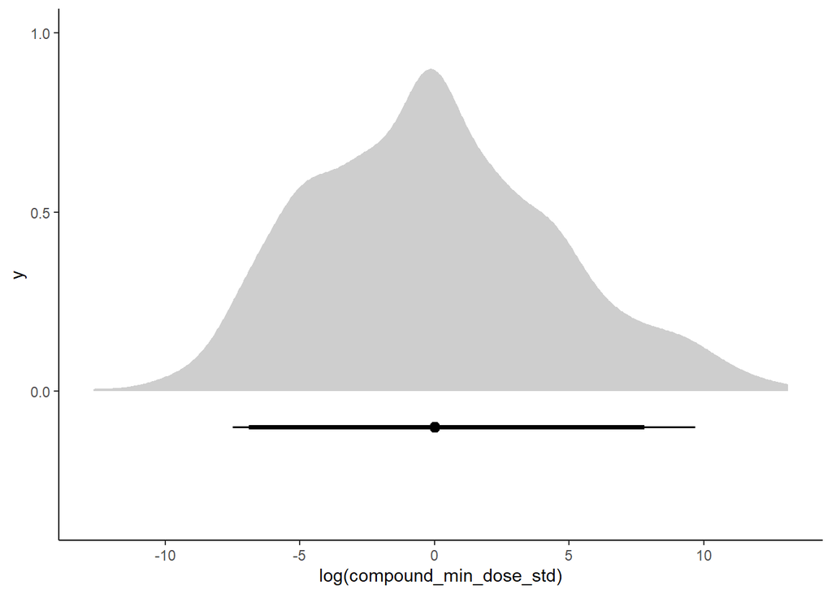

```r
env_min_conc_fig <- EIPAAB_database %>%
    dplyr::filter(study_motivation == "Environmental") %>%
    dplyr::filter(compound_min_dose_unit_std == "ug/L") %>%
    ggplot(aes(x = log(compound_min_dose_std))) + stat_slab(aes(alpha = 0.8, linewidth = 1.5)) +
    stat_pointinterval(point_interval = "median_qi", position = position_dodge(width = 0.4,
        preserve = "single"), .width = c(0.89, 0.95)) + theme_classic() + theme(legend.position = "none")

env_min_conc_fig
```

A summary table so we can see what the corresponding raw values are in the plot

```r
env_conc_summary <- EIPAAB_database %>%
    filter(study_motivation == "Environmental", compound_min_dose_unit_std == "ug/L") %>%
    summarise(median = median(log(compound_min_dose_std), na.rm = TRUE), lower_89 = quantile(log(compound_min_dose_std),
        probs = 0.055, na.rm = TRUE), upper_89 = quantile(log(compound_min_dose_std),
        probs = 0.945, na.rm = TRUE), lower_95 = quantile(log(compound_min_dose_std),
        probs = 0.025, na.rm = TRUE), upper_95 = quantile(log(compound_min_dose_std),
        probs = 0.975, na.rm = TRUE)) %>%
    # Transform to a format suitable for ggplot annotation
pivot_longer(cols = everything(), names_to = "stat", values_to = "value") %>%
    dplyr::mutate(vaule_raw = format(exp(value), scientific = FALSE))
env_conc_summary %>%
    gt()
```

| stat | value | vaule_raw |
| --- | --- | --- |
| median | -0.005025168 | 0.9949874371 |
| lower_89 | -6.907755279 | 0.0010000000 |
| upper_89 | 7.793933105 | 2425.8399279662 |
| lower_95 | -7.489709151 | 0.0005588055 |
| upper_95 | 9.674172499 | 15901.5600424659 |

### 10.7.9 Exposure location

Where the exposure itself was conducted

```r
EIPAAB_database %>%
    dplyr::group_by(compound_exposure_location) %>%
    dplyr::reframe(n = n()) %>%
    dplyr::mutate(total = sum(n), perecent = round(n/total * 100, 1)) %>%
    gt()
```

| compound_exposure_location | n | total | perecent |
| --- | --- | --- | --- |
| Indoor laboratory setting or assumed indoors | 1729 | 1739 | 99.4 |
| Outdoor natural setting | 4 | 1739 | 0.2 |
| Outdoor restricted setting (cannot interact with wild species) | 6 | 1739 | 0.3 |

## 10.8 Behaviour

### 10.8.1 Counts of catagoires

First I will make a new variable called beahv_catgory_n, which will look at how many of our 10 broad behavioural categories were measured in the article.

The 10 over-arching categories were: (1) movement and locomotion, (2) pre-mating and mating behaviour, (3) post-mating behaviour, (4) aggression, (5) sociality, (6) cognition and learning, (7) anxiety and boldness, (8) foraging and feeding, (9) antipredator behaviour, and (10) other behaviours not categorised

This will take the some of all the behaviour categories., so can range from 1 to 10 for a single behavioural category to all categories.

```r
EIPAAB_database <- EIPAAB_database %>%
    dplyr::mutate(behav_category_n = rowSums(across(starts_with("behav_") & ends_with("_boolean"))))
```

The majority of evidence seems to be based on a single behavioural category

```r
EIPAAB_database %>%
    dplyr::group_by(behav_category_n) %>%
    dplyr::reframe(n = n()) %>%
    dplyr::mutate(percent = round(n/sum(n) * 100, 1)) %>%
    gt()
```

| behav_category_n | n | percent |
| --- | --- | --- |
| 1 | 1205 | 69.3 |
| 2 | 400 | 23.0 |
| 3 | 115 | 6.6 |
| 4 | 16 | 0.9 |
| 5 | 2 | 0.1 |
| 7 | 1 | 0.1 |

Is this the same by study motivation

```r
EIPAAB_database %>%
    dplyr::group_by(behav_category_n, study_motivation) %>%
    dplyr::reframe(n = n()) %>%
    dplyr::group_by(study_motivation) %>%
    dplyr::mutate(total_motivation = sum(n)) %>%
    dplyr::ungroup() %>%
    dplyr::mutate(percent = round(n/total_motivation * 100, 1)) %>%
    gt()
```

| behav_category_n | study_motivation | n | total_motivation | percent |
| --- | --- | --- | --- | --- |
| 1 | Environmental | 593 | 858 | 69.1 |
| 1 | Medical | 378 | 518 | 73.0 |
| 1 | Basic research | 234 | 363 | 64.5 |
| 2 | Environmental | 180 | 858 | 21.0 |
| 2 | Medical | 110 | 518 | 21.2 |
| 2 | Basic research | 110 | 363 | 30.3 |
| 3 | Environmental | 75 | 858 | 8.7 |
| 3 | Medical | 25 | 518 | 4.8 |
| 3 | Basic research | 15 | 363 | 4.1 |
| 4 | Environmental | 8 | 858 | 0.9 |
| 4 | Medical | 4 | 518 | 0.8 |
| 4 | Basic research | 4 | 363 | 1.1 |
| 5 | Environmental | 2 | 858 | 0.2 |
| 7 | Medical | 1 | 518 | 0.2 |

Here I make a dataframe where I have pivoted the data to long formate based on each of the 10 behaviour categories. This data frame can be used to ask more specific questions about the relationship between species, compound, and behaviour.

But first let’s use it to see what behaviours are most common overall all, and within each study motivation.

```r
binary_behav <- EIPAAB_database %>%
    dplyr::select((starts_with("behav_") & ends_with("_boolean"))) %>%
    colnames()

PICO_long <- EIPAAB_database %>%
    tidyr::pivot_longer(., cols = all_of(binary_behav), names_to = "behav_category",
        values_to = "value") %>%
    dplyr::select(article_id, study_motivation, species_name, species_class, compound_name,
        compound_atc_level_3, behav_category, value) %>%
    dplyr::mutate(behav_category = behav_category %>%
        str_remove("behav_") %>%
        str_remove("_boolean"))

PICO_long %>%
    head() %>%
    gt()
```

| article_id | study_motivation | species_name | species_class | compound_name | compound_atc_level_3 | behav_category | value |
| --- | --- | --- | --- | --- | --- | --- | --- |
| 236660465 | Environmental | Danio rerio | Actinopterygii | Buspirone | n05b anxiolytics | movement | 0 |
| 236660465 | Environmental | Danio rerio | Actinopterygii | Buspirone | n05b anxiolytics | boldness | 1 |
| 236660465 | Environmental | Danio rerio | Actinopterygii | Buspirone | n05b anxiolytics | foraging | 0 |
| 236660465 | Environmental | Danio rerio | Actinopterygii | Buspirone | n05b anxiolytics | antipredator | 0 |
| 236660465 | Environmental | Danio rerio | Actinopterygii | Buspirone | n05b anxiolytics | mating | 0 |
| 236660465 | Environmental | Danio rerio | Actinopterygii | Buspirone | n05b anxiolytics | post_mating | 0 |

Overall use of behaviour

```r
behav_overall <- PICO_long %>%
    dplyr::group_by(behav_category) %>%
    reframe(n = sum(value)) %>%
    dplyr::mutate(percent = round(n/sum(n) * 100, 1)) %>%
    dplyr::arrange(desc(n))
behav_overall %>%
    gt()
```

| behav_category | n | percent |
| --- | --- | --- |
| movement | 983 | 40.4 |
| boldness | 567 | 23.3 |
| foraging | 190 | 7.8 |
| agression | 145 | 6.0 |
| sociality | 143 | 5.9 |
| mating | 122 | 5.0 |
| noncat | 96 | 3.9 |
| cognition | 90 | 3.7 |
| antipredator | 85 | 3.5 |
| post_mating | 10 | 0.4 |

By study motivation

```r
behav_motivation <- PICO_long %>%
    dplyr::group_by(behav_category, study_motivation) %>%
    dplyr::summarise(n = sum(value), .groups = "drop") %>%
    tidyr::complete(behav_category, study_motivation, fill = list(n = 0)) %>%
    dplyr::group_by(study_motivation) %>%
    dplyr::mutate(total_motivation = sum(n)) %>%
    dplyr::ungroup() %>%
    dplyr::mutate(percent = round(n/total_motivation * 100, 1)) %>%
    dplyr::select(-total_motivation) %>%
    dplyr::arrange(desc(study_motivation))

behav_overall <- behav_motivation %>%
    dplyr::group_by(behav_category) %>%
    dplyr::reframe(n = sum(n)) %>%
    dplyr::mutate(percent = round(n/sum(n) * 100, 1), study_motivation = "Overall")

behav_motivation <- rbind(behav_overall, behav_motivation)
```

#### 10.8.1.1 Fig 6

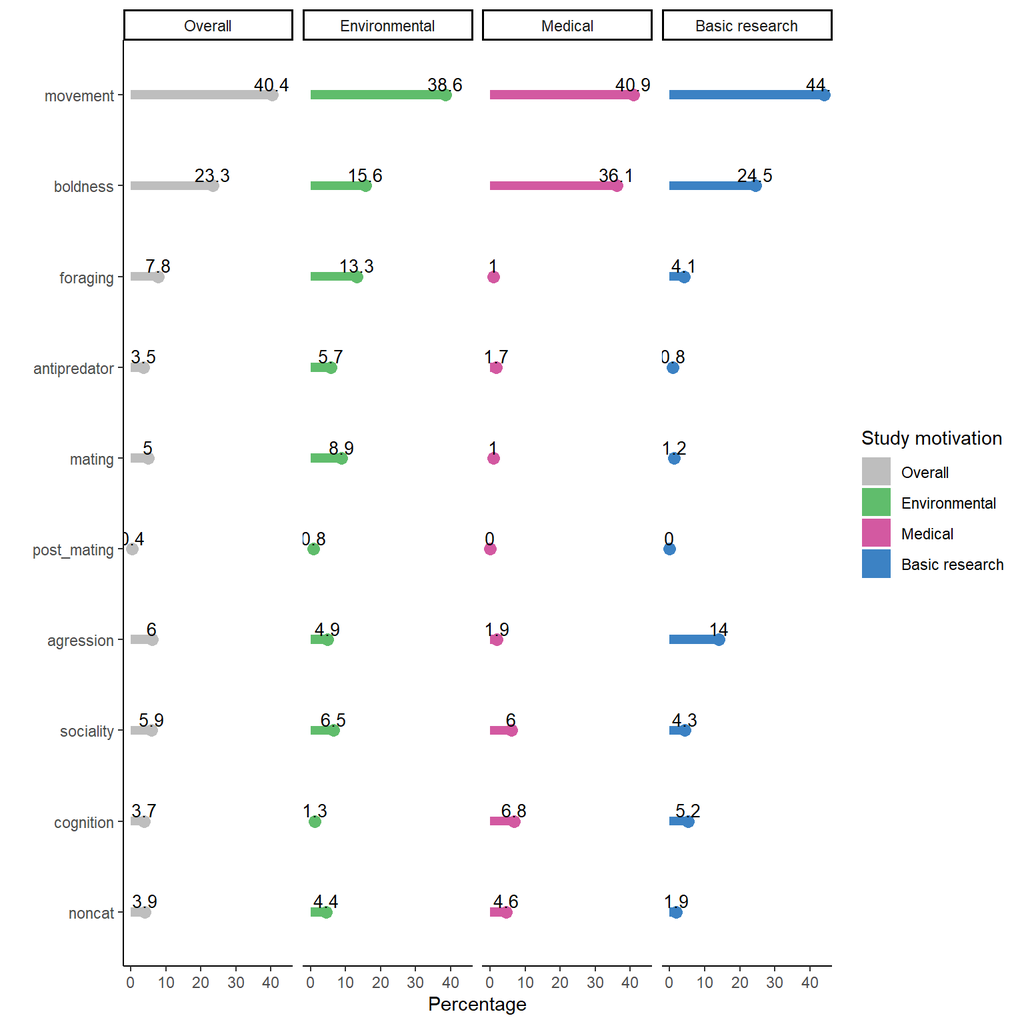

```r
motivation_colour_theme <- c("grey", "#60BD6C", "#D359A1", "#3C82C4")
behav_order <- c("movement", "boldness", "foraging", "antipredator", "mating", "post_mating",
    "agression", "sociality", "cognition", "noncat")
study_motivation_order <- c("Overall", "Environmental", "Medical", "Basic research")


behav_motivation_fig <- behav_motivation %>%
    dplyr::mutate(behav_category = factor(behav_category, levels = rev(behav_order)),
        study_motivation = factor(study_motivation, levels = study_motivation_order)) %>%
    ggplot(aes(x = behav_category, y = percent, colour = study_motivation, fill = study_motivation),
        group = study_motivation) + geom_col(width = 0.1, colour = NA) + geom_point(size = 3) +
    geom_text(aes(label = percent), vjust = -0.3, size = 3.5, color = "black") +
    theme_classic() + facet_grid(cols = vars(study_motivation)) + scale_colour_manual(values = motivation_colour_theme,
    name = "Study motivation") + scale_fill_manual(values = motivation_colour_theme,
    name = "Study motivation") + coord_flip() + labs(x = "", y = "Percentage") +
    theme(plot.title = element_text(size = 11))

behav_motivation_fig
```

Save the figure

```r
# setwd(figures_path) ggsave('behav_motivation_fig.pdf', plot =
# behav_motivation_fig, width = 10, height = 5)
```

### 10.8.2 Behaviour sub-categories

```r
behav_select <- EIPAAB_database %>%
    dplyr::select((starts_with("behav_") & !ends_with("_boolean") & !ends_with("is_social_context") &
        !ends_with("test_location") & !ends_with("category_n"))) %>%
    colnames()


behav_sub_cat_long <- EIPAAB_database %>%
    tidyr::pivot_longer(., cols = all_of(behav_select), names_to = "parent_category",
        values_to = "sub_category") %>%
    dplyr::select(article_id, study_motivation, species_name, species_class, compound_name,
        compound_atc_level_3, parent_category, sub_category) %>%
    dplyr::mutate(parent_category = parent_category %>%
        str_remove("behav_")) %>%
    tidyr::separate_rows(sub_category, sep = ";") %>%
    dplyr::filter(!is.na(sub_category))
```

Now a summary data file with sub-categories.

```r
behav_sub_cat_summary <- behav_sub_cat_long %>%
    dplyr::group_by(study_motivation, parent_category, sub_category) %>%
    dplyr::summarise(n_sub_cat = n(), .groups = "drop") %>%
    dplyr::group_by(study_motivation, parent_category) %>%
    dplyr::mutate(n_parent = sum(n_sub_cat)) %>%
    dplyr::ungroup() %>%
    dplyr::group_by(study_motivation) %>%
    dplyr::mutate(n_motivation = sum(n_sub_cat)) %>%
    dplyr::ungroup() %>%
    dplyr::mutate(percent_sub_cat = n_sub_cat/n_parent, percent_parent = n_parent/n_motivation)

behav_sub_cat_summary %>%
    head() %>%
    gt()
```

| study_motivation | parent_category | sub_category | n_sub_cat | n_parent | n_motivation | percent_sub_cat | percent_parent |
| --- | --- | --- | --- | --- | --- | --- | --- |
| Environmental | agression | aggression towards a live competitor free to interact | 27 | 70 | 1511 | 0.38571429 | 0.04632694 |
| Environmental | agression | aggression towards a live competitor with physical barrier | 10 | 70 | 1511 | 0.14285714 | 0.04632694 |
| Environmental | agression | aggression towards a mirror | 20 | 70 | 1511 | 0.28571429 | 0.04632694 |
| Environmental | agression | aggression towards a model or video | 7 | 70 | 1511 | 0.10000000 | 0.04632694 |
| Environmental | agression | locomotor activity within this context | 6 | 70 | 1511 | 0.08571429 | 0.04632694 |
| Environmental | antipredator | locomotor activity within this context | 22 | 100 | 1511 | 0.22000000 | 0.06618134 |

Formating the data for a ring plot.

```r
ring_plot_subcat <- behav_sub_cat_summary %>%
    dplyr::group_by(study_motivation, parent_category) %>%
    dplyr::mutate(ymax = cumsum(percent_sub_cat), ymin = lag(ymax, 1), ymin = if_else(is.na(ymin),
        0, ymin), labelPosition = (ymax + ymin)/2, label = paste0(sub_category, "\n (n = ",
        n_sub_cat, ")")) %>%
    dplyr::ungroup()
```

#### 10.8.2.1 Movement plots

First making a complete dataset (adding zeros for missing sub-categories. in each motivation), and ordering by overall prevalence of sub-categories.

```r
sub_category_order <- behav_sub_cat_summary %>%
    dplyr::filter(parent_category == "movement") %>%
    dplyr::group_by(sub_category) %>%
    dplyr::reframe(n = sum(n_sub_cat)) %>%
    dplyr::arrange(n) %>%
    dplyr::pull(sub_category)

movement_subcat <- behav_sub_cat_summary %>%
    dplyr::filter(parent_category == "movement") %>%
    dplyr::select(study_motivation, sub_category, percent_sub_cat, n_sub_cat, percent_parent) %>%
    tidyr::complete(sub_category, study_motivation, fill = list(percent_sub_cat = 0,
        n_sub_cat = 0)) %>%
    dplyr::mutate(sub_category = factor(sub_category, levels = sub_category_order))
```

##### 10.8.2.1.1 Fig S6-1

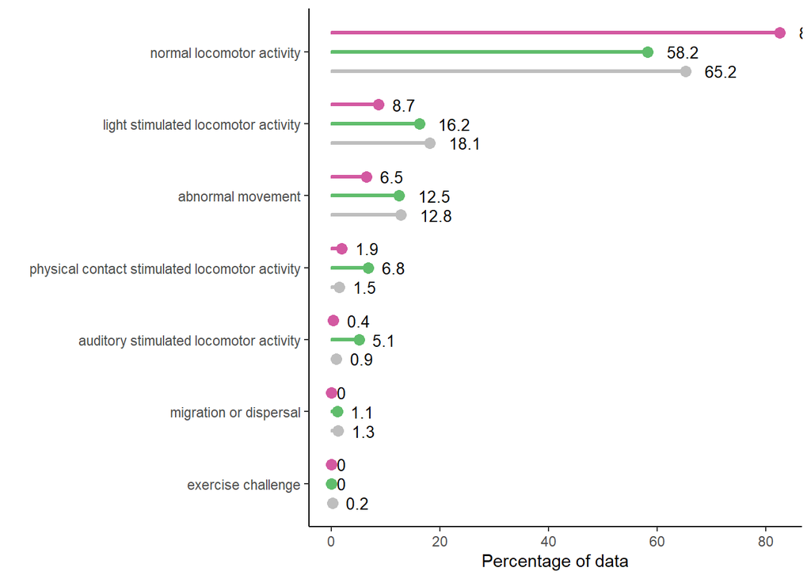

```r
beh_movement_subcat_fig <- movement_subcat %>%
    dplyr::mutate(percent_sub_cat = round(percent_sub_cat, 3) * 100) %>%
    ggplot(aes(x = sub_category, y = percent_sub_cat, colour = study_motivation,
        fill = study_motivation, group = study_motivation)) + geom_col(position = position_dodge(width = 0.8),
    width = 0.1) + geom_point(position = position_dodge(width = 0.8), size = 3) +
    geom_text(aes(label = percent_sub_cat), hjust = -0.6, size = 3.5, color = "black",
        position = position_dodge(width = 0.8)) + scale_colour_manual(values = motivation_colour_theme,
    name = "Study motivation") + scale_fill_manual(values = motivation_colour_theme,
    name = "Study motivation") + theme_classic() + coord_flip() + labs(x = "", y = "Percentage of data") +
    theme(legend.position = "none")

beh_movement_subcat_fig
```

Save the figure

```r
# n_subcat <- movement_subcat %>% dplyr::distinct(sub_category) %>% nrow(.)/10
# setwd(figures_path) ggsave('beh_movement_subcat_fig.pdf', plot =
# beh_movement_subcat_fig, width = 10, height = 11.7*n_subcat)
```

If you would like to make a doughnut chart here’s the code. However, for categories that have 5 or more sub-categories like movement I don’t think this is the clearest way to present the data.

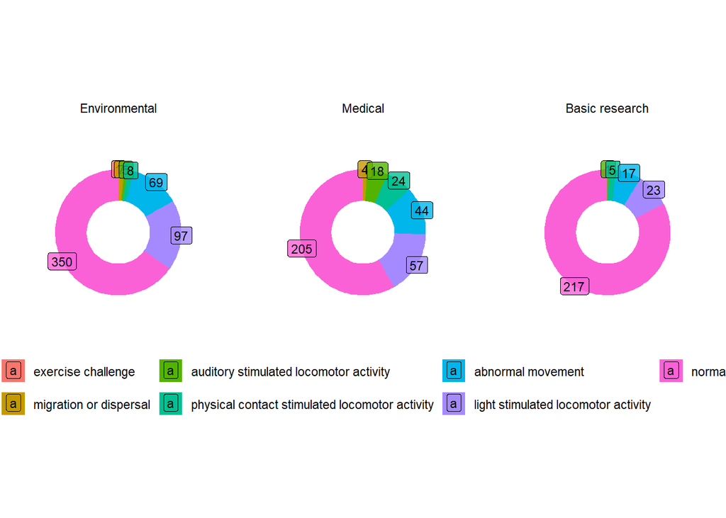

```r
movement_subcat %>%
    dplyr::arrange(sub_category) %>%
    dplyr::arrange(study_motivation) %>%
    dplyr::group_by(study_motivation) %>%
    dplyr::mutate(ymax = cumsum(percent_sub_cat), ymin = lag(ymax, 1), ymin = if_else(is.na(ymin),
        0, ymin), labelPosition = (ymax + ymin)/2, label = if_else(n_sub_cat == 0,
        NA, n_sub_cat)) %>%
    dplyr::ungroup() %>%
    ggplot(aes(ymax = ymax, ymin = ymin, xmax = 4, xmin = 3, fill = sub_category)) +
    geom_rect() + coord_polar(theta = "y") + geom_label(x = 4, aes(y = labelPosition,
    label = label), size = 3, alpha = 0.8) + facet_wrap(~study_motivation) + xlim(c(2,
    5)) + theme_void() + theme(legend.position = "bottom")
```

#### 10.8.2.2 Boldness plots

```r
sub_category_order <- behav_sub_cat_summary %>%
    dplyr::filter(parent_category == "boldness") %>%
    dplyr::group_by(sub_category) %>%
    dplyr::reframe(n = sum(n_sub_cat)) %>%
    dplyr::arrange(n) %>%
    dplyr::pull(sub_category)

boldness_subcat <- behav_sub_cat_summary %>%
    dplyr::filter(parent_category == "boldness") %>%
    dplyr::select(study_motivation, sub_category, percent_sub_cat, n_sub_cat, percent_parent) %>%
    tidyr::complete(sub_category, study_motivation, fill = list(percent_sub_cat = 0,
        n_sub_cat = 0)) %>%
    dplyr::mutate(sub_category = factor(sub_category, levels = sub_category_order))
```

##### 10.8.2.2.1 Fig S6-2

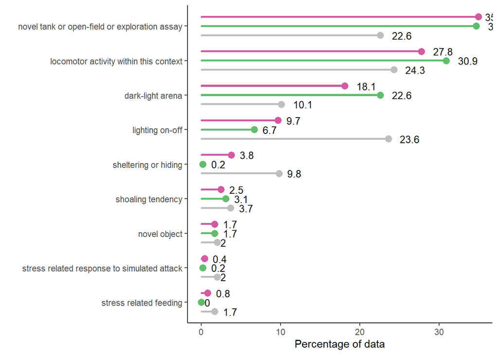

```r
beh_boldness_subcat_fig <- boldness_subcat %>%
    dplyr::mutate(percent_sub_cat = round(percent_sub_cat, 3) * 100) %>%
    ggplot(aes(x = sub_category, y = percent_sub_cat, colour = study_motivation,
        fill = study_motivation, group = study_motivation)) + geom_col(position = position_dodge(width = 0.8),
    width = 0.1) + geom_point(position = position_dodge(width = 0.8), size = 3) +
    geom_text(aes(label = percent_sub_cat), hjust = -0.6, size = 3.5, color = "black",
        position = position_dodge(width = 0.8)) + scale_colour_manual(values = motivation_colour_theme,
    name = "Study motivation") + scale_fill_manual(values = motivation_colour_theme,
    name = "Study motivation") + theme_classic() + coord_flip() + labs(x = "", y = "Percentage of data") +
    theme(legend.position = "none")

beh_boldness_subcat_fig
```

Save the figure

```r
# n_subcat <- boldness_subcat %>% dplyr::distinct(sub_category) %>% nrow(.)/10
# setwd(figures_path) ggsave('beh_boldness_subcat_fig.pdf', plot =
# beh_boldness_subcat_fig, width = 10, height = 11.7*n_subcat)
```

#### 10.8.2.3 Foraging plots

```r
sub_category_order <- behav_sub_cat_summary %>%
    dplyr::filter(parent_category == "foraging") %>%
    dplyr::group_by(sub_category) %>%
    dplyr::reframe(n = sum(n_sub_cat)) %>%
    dplyr::arrange(n) %>%
    dplyr::pull(sub_category)

foraging_subcat <- behav_sub_cat_summary %>%
    dplyr::filter(parent_category == "foraging") %>%
    dplyr::select(study_motivation, sub_category, percent_sub_cat, n_sub_cat, percent_parent) %>%
    tidyr::complete(sub_category, study_motivation, fill = list(percent_sub_cat = 0,
        n_sub_cat = 0)) %>%
    dplyr::mutate(sub_category = factor(sub_category, levels = sub_category_order))
```

##### 10.8.2.3.1 Fig S6-3

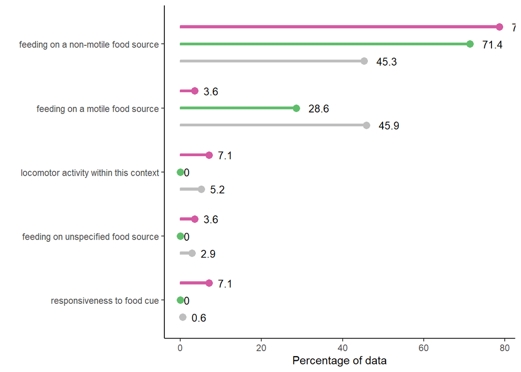

```r
beh_foraging_subcat_fig <- foraging_subcat %>%
    dplyr::mutate(percent_sub_cat = round(percent_sub_cat, 3) * 100) %>%
    ggplot(aes(x = sub_category, y = percent_sub_cat, colour = study_motivation,
        fill = study_motivation, group = study_motivation)) + geom_col(position = position_dodge(width = 0.8),
    width = 0.1) + geom_point(position = position_dodge(width = 0.8), size = 3) +
    geom_text(aes(label = percent_sub_cat), hjust = -0.6, size = 3.5, color = "black",
        position = position_dodge(width = 0.8)) + scale_colour_manual(values = motivation_colour_theme,
    name = "Study motivation") + scale_fill_manual(values = motivation_colour_theme,
    name = "Study motivation") + theme_classic() + coord_flip() + labs(x = "", y = "Percentage of data") +
    theme(legend.position = "none")

beh_foraging_subcat_fig
```

Save the figure

```r
# n_subcat <- foraging_subcat %>% dplyr::distinct(sub_category) %>% nrow(.)/10
# setwd(figures_path) ggsave('beh_foraging_subcat_fig.pdf', plot =
# beh_foraging_subcat_fig, width = 10, height = 11.7*n_subcat)
```

#### 10.8.2.4 Antipredator plots

```r
sub_category_order <- behav_sub_cat_summary %>%
    dplyr::filter(parent_category == "antipredator") %>%
    dplyr::group_by(sub_category) %>%
    dplyr::reframe(n = sum(n_sub_cat)) %>%
    dplyr::arrange(n) %>%
    dplyr::pull(sub_category)

antipredator_subcat <- behav_sub_cat_summary %>%
    dplyr::filter(parent_category == "antipredator") %>%
    dplyr::select(study_motivation, sub_category, percent_sub_cat, n_sub_cat, percent_parent) %>%
    tidyr::complete(sub_category, study_motivation, fill = list(percent_sub_cat = 0,
        n_sub_cat = 0)) %>%
    dplyr::mutate(sub_category = factor(sub_category, levels = sub_category_order))
```

##### 10.8.2.4.1 Fig S6-4

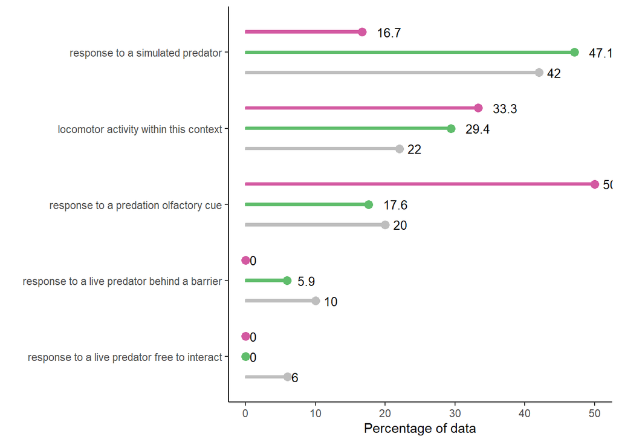

```r
beh_antipredator_subcat_fig <- antipredator_subcat %>%
    dplyr::mutate(percent_sub_cat = round(percent_sub_cat, 3) * 100) %>%
    ggplot(aes(x = sub_category, y = percent_sub_cat, colour = study_motivation,
        fill = study_motivation, group = study_motivation)) + geom_col(position = position_dodge(width = 0.8),
    width = 0.1) + geom_point(position = position_dodge(width = 0.8), size = 3) +
    geom_text(aes(label = percent_sub_cat), hjust = -0.6, size = 3.5, color = "black",
        position = position_dodge(width = 0.8)) + scale_colour_manual(values = motivation_colour_theme,
    name = "Study motivation") + scale_fill_manual(values = motivation_colour_theme,
    name = "Study motivation") + theme_classic() + coord_flip() + labs(x = "", y = "Percentage of data") +
    theme(legend.position = "none")

beh_antipredator_subcat_fig
```

Save figure

```r
# n_subcat <- antipredator_subcat %>% dplyr::distinct(sub_category) %>%
# nrow(.)/10 setwd(figures_path) ggsave('beh_antipredator_subcat_fig.pdf', plot
# = beh_antipredator_subcat_fig, width = 10, height = 11.7*n_subcat)
```

#### 10.8.2.5 Mating plots

```r
sub_category_order <- behav_sub_cat_summary %>%
    dplyr::filter(parent_category == "mating") %>%
    dplyr::group_by(sub_category) %>%
    dplyr::reframe(n = sum(n_sub_cat)) %>%
    dplyr::arrange(n) %>%
    dplyr::pull(sub_category)

mating_subcat <- behav_sub_cat_summary %>%
    dplyr::filter(parent_category == "mating") %>%
    dplyr::select(study_motivation, sub_category, percent_sub_cat, n_sub_cat, percent_parent) %>%
    tidyr::complete(sub_category, study_motivation, fill = list(percent_sub_cat = 0,
        n_sub_cat = 0)) %>%
    dplyr::mutate(sub_category = factor(sub_category, levels = sub_category_order))
```

##### 10.8.2.5.1 Fig S6-5

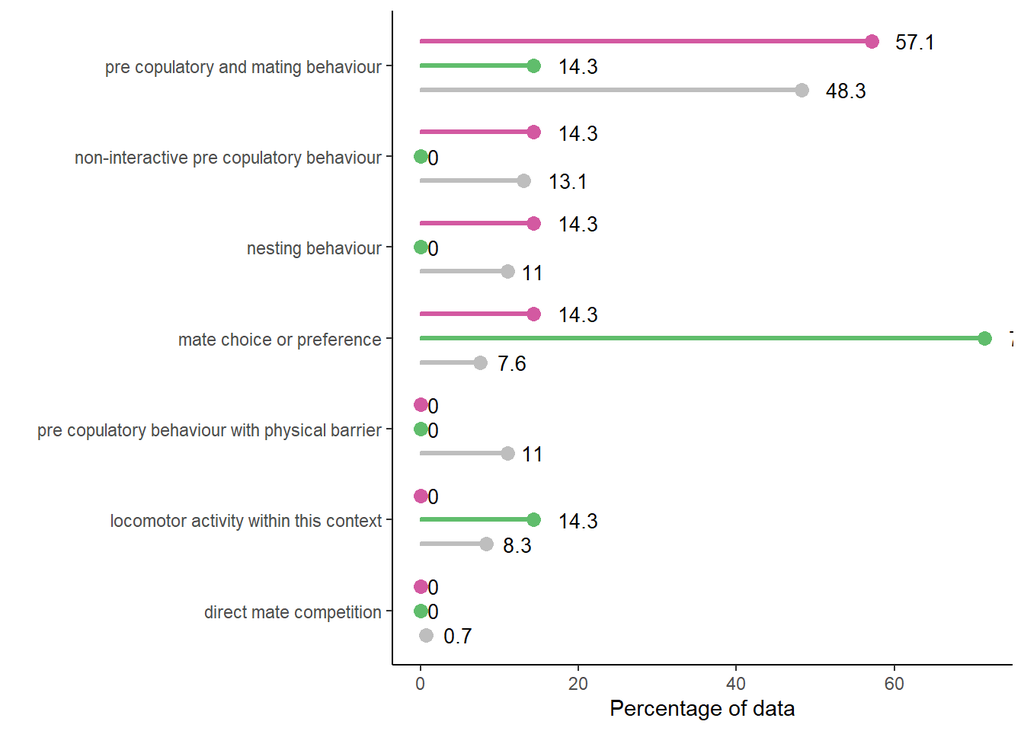

```r
beh_mating_subcat_fig <- mating_subcat %>%
    dplyr::mutate(percent_sub_cat = round(percent_sub_cat, 3) * 100) %>%
    ggplot(aes(x = sub_category, y = percent_sub_cat, colour = study_motivation,
        fill = study_motivation, group = study_motivation)) + geom_col(position = position_dodge(width = 0.8),
    width = 0.1) + geom_point(position = position_dodge(width = 0.8), size = 3) +
    geom_text(aes(label = percent_sub_cat), hjust = -0.6, size = 3.5, color = "black",
        position = position_dodge(width = 0.8)) + scale_colour_manual(values = motivation_colour_theme,
    name = "Study motivation") + scale_fill_manual(values = motivation_colour_theme,
    name = "Study motivation") + theme_classic() + coord_flip() + labs(x = "", y = "Percentage of data") +
    theme(legend.position = "none")

beh_mating_subcat_fig
```

Save the figure

```r
# n_subcat <- mating_subcat %>% dplyr::distinct(sub_category) %>% nrow(.)/10
# setwd(figures_path) ggsave('beh_mating_subcat_fig.pdf', plot =
# beh_mating_subcat_fig, width = 10, height = 11.7*n_subcat)
```

#### 10.8.2.6 Post mating plots

```r
sub_category_order <- behav_sub_cat_summary %>%
    dplyr::filter(parent_category == "post_mating") %>%
    dplyr::group_by(sub_category) %>%
    dplyr::reframe(n = sum(n_sub_cat)) %>%
    dplyr::arrange(n) %>%
    dplyr::pull(sub_category)

post_mating_subcat <- behav_sub_cat_summary %>%
    dplyr::filter(parent_category == "post_mating") %>%
    dplyr::select(study_motivation, sub_category, percent_sub_cat, n_sub_cat, percent_parent) %>%
    tidyr::complete(sub_category, study_motivation, fill = list(percent_sub_cat = 0,
        n_sub_cat = 0)) %>%
    dplyr::mutate(sub_category = factor(sub_category, levels = sub_category_order))
```

##### 10.8.2.6.1 Fig S6-6

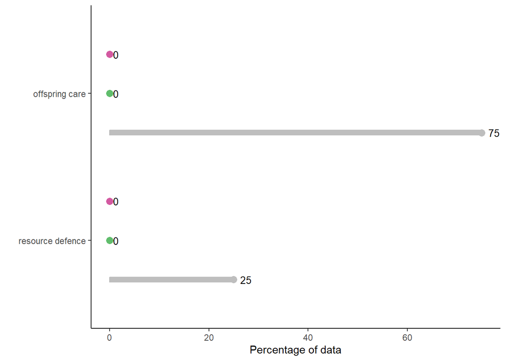

```r
beh_post_mating_subcat_fig <- post_mating_subcat %>%
    dplyr::mutate(percent_sub_cat = round(percent_sub_cat, 3) * 100) %>%
    ggplot(aes(x = sub_category, y = percent_sub_cat, colour = study_motivation,
        fill = study_motivation, group = study_motivation)) + geom_col(position = position_dodge(width = 0.8),
    width = 0.1) + geom_point(position = position_dodge(width = 0.8), size = 3) +
    geom_text(aes(label = percent_sub_cat), hjust = -0.6, size = 3.5, color = "black",
        position = position_dodge(width = 0.8)) + scale_colour_manual(values = motivation_colour_theme,
    name = "Study motivation") + scale_fill_manual(values = motivation_colour_theme,
    name = "Study motivation") + theme_classic() + coord_flip() + labs(x = "", y = "Percentage of data") +
    theme(legend.position = "none")

beh_post_mating_subcat_fig
```

Save the figure

```r
# n_subcat <- post_mating_subcat %>% dplyr::distinct(sub_category) %>%
# nrow(.)/10 setwd(figures_path) ggsave('beh_post_mating_subcat_fig.pdf', plot
# = beh_post_mating_subcat_fig, width = 10, height = 11.7*n_subcat)
```

#### 10.8.2.7 Agression plots

```r
sub_category_order <- behav_sub_cat_summary %>%
    dplyr::filter(parent_category == "agression") %>%
    dplyr::group_by(sub_category) %>%
    dplyr::reframe(n = sum(n_sub_cat)) %>%
    dplyr::arrange(n) %>%
    dplyr::pull(sub_category)

agression_subcat <- behav_sub_cat_summary %>%
    dplyr::filter(parent_category == "agression") %>%
    dplyr::select(study_motivation, sub_category, percent_sub_cat, n_sub_cat, percent_parent) %>%
    tidyr::complete(sub_category, study_motivation, fill = list(percent_sub_cat = 0,
        n_sub_cat = 0)) %>%
    dplyr::mutate(sub_category = factor(sub_category, levels = sub_category_order))
```

##### 10.8.2.7.1 Fig S6-7

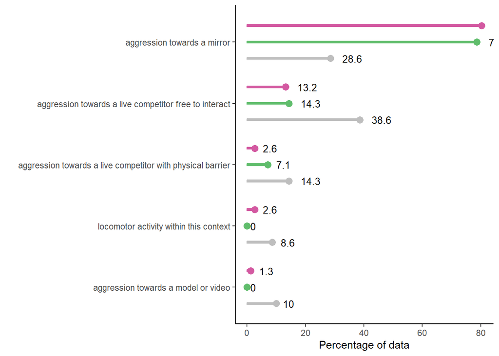

```r
beh_agression_subcat_fig <- agression_subcat %>%
    dplyr::mutate(percent_sub_cat = round(percent_sub_cat, 3) * 100) %>%
    ggplot(aes(x = sub_category, y = percent_sub_cat, colour = study_motivation,
        fill = study_motivation, group = study_motivation)) + geom_col(position = position_dodge(width = 0.8),
    width = 0.1) + geom_point(position = position_dodge(width = 0.8), size = 3) +
    geom_text(aes(label = percent_sub_cat), hjust = -0.6, size = 3.5, color = "black",
        position = position_dodge(width = 0.8)) + scale_colour_manual(values = motivation_colour_theme,
    name = "Study motivation") + scale_fill_manual(values = motivation_colour_theme,
    name = "Study motivation") + theme_classic() + coord_flip() + labs(x = "", y = "Percentage of data") +
    theme(legend.position = "none")

beh_agression_subcat_fig
```

Save the figure

```r
# n_subcat <- agression_subcat %>% dplyr::distinct(sub_category) %>% nrow(.)/10
# setwd(figures_path) ggsave('beh_agression_subcat_fig.pdf', plot =
# beh_agression_subcat_fig, width = 10, height = 11.7*n_subcat)
```

#### 10.8.2.8 Sociality plots

```r
sub_category_order <- behav_sub_cat_summary %>%
    dplyr::filter(parent_category == "sociality") %>%
    dplyr::group_by(sub_category) %>%
    dplyr::reframe(n = sum(n_sub_cat)) %>%
    dplyr::arrange(n) %>%
    dplyr::pull(sub_category)

sociality_subcat <- behav_sub_cat_summary %>%
    dplyr::filter(parent_category == "sociality") %>%
    dplyr::select(study_motivation, sub_category, percent_sub_cat, n_sub_cat, percent_parent) %>%
    tidyr::complete(sub_category, study_motivation, fill = list(percent_sub_cat = 0,
        n_sub_cat = 0)) %>%
    dplyr::mutate(sub_category = factor(sub_category, levels = sub_category_order))
```

##### 10.8.2.8.1 Fig S6-8

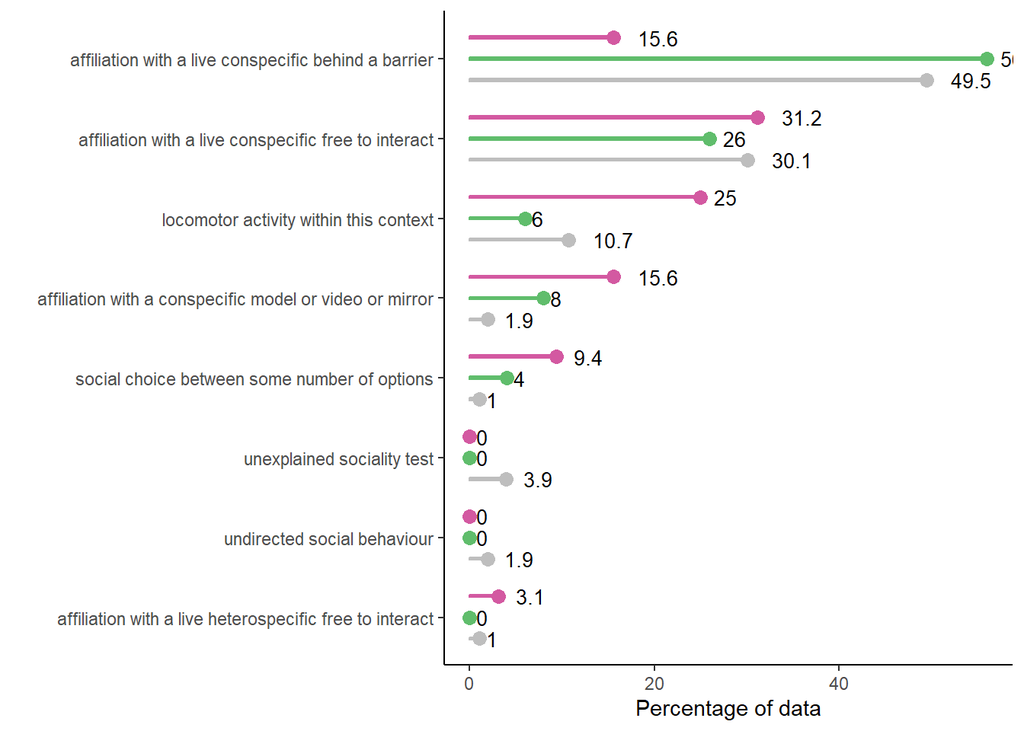

```r
beh_sociality_subcat_fig <- sociality_subcat %>%
    dplyr::mutate(percent_sub_cat = round(percent_sub_cat, 3) * 100) %>%
    ggplot(aes(x = sub_category, y = percent_sub_cat, colour = study_motivation,
        fill = study_motivation, group = study_motivation)) + geom_col(position = position_dodge(width = 0.8),
    width = 0.1) + geom_point(position = position_dodge(width = 0.8), size = 3) +
    geom_text(aes(label = percent_sub_cat), hjust = -0.6, size = 3.5, color = "black",
        position = position_dodge(width = 0.8)) + scale_colour_manual(values = motivation_colour_theme,
    name = "Study motivation") + scale_fill_manual(values = motivation_colour_theme,
    name = "Study motivation") + theme_classic() + coord_flip() + labs(x = "", y = "Percentage of data") +
    theme(legend.position = "none")

beh_sociality_subcat_fig
```

Save the figure

```r
# n_subcat <- sociality_subcat %>% dplyr::distinct(sub_category) %>% nrow(.)/10
# setwd(figures_path) ggsave('beh_sociality_subcat_fig.pdf', plot =
# beh_sociality_subcat_fig, width = 10, height = 11.7*n_subcat)
```

#### 10.8.2.9 Cognition plots

```r
sub_category_order <- behav_sub_cat_summary %>%
    dplyr::filter(parent_category == "cognition") %>%
    dplyr::group_by(sub_category) %>%
    dplyr::reframe(n = sum(n_sub_cat)) %>%
    dplyr::arrange(n) %>%
    dplyr::pull(sub_category)

cognition_subcat <- behav_sub_cat_summary %>%
    dplyr::filter(parent_category == "cognition") %>%
    dplyr::select(study_motivation, sub_category, percent_sub_cat, n_sub_cat, percent_parent) %>%
    tidyr::complete(sub_category, study_motivation, fill = list(percent_sub_cat = 0,
        n_sub_cat = 0)) %>%
    dplyr::mutate(sub_category = factor(sub_category, levels = sub_category_order))
```

##### 10.8.2.9.1 Fig S6-9

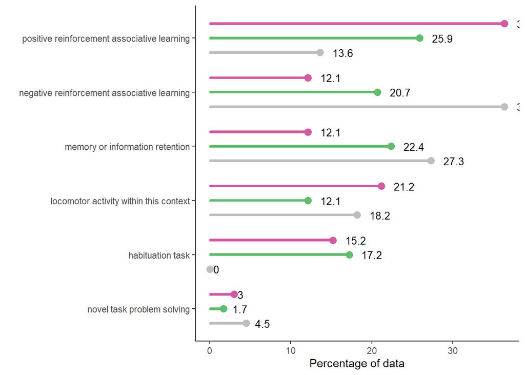

```r
beh_cognition_subcat_fig <- cognition_subcat %>%
    dplyr::mutate(percent_sub_cat = round(percent_sub_cat, 3) * 100) %>%
    ggplot(aes(x = sub_category, y = percent_sub_cat, colour = study_motivation,
        fill = study_motivation, group = study_motivation)) + geom_col(position = position_dodge(width = 0.8),
    width = 0.1) + geom_point(position = position_dodge(width = 0.8), size = 3) +
    geom_text(aes(label = percent_sub_cat), hjust = -0.6, size = 3.5, color = "black",
        position = position_dodge(width = 0.8)) + scale_colour_manual(values = motivation_colour_theme,
    name = "Study motivation") + scale_fill_manual(values = motivation_colour_theme,
    name = "Study motivation") + theme_classic() + coord_flip() + labs(x = "", y = "Percentage of data") +
    theme(legend.position = "none")

beh_cognition_subcat_fig
```

Save the figure

```r
# n_subcat <- cognition_subcat %>% dplyr::distinct(sub_category) %>% nrow(.)/10
# setwd(figures_path) ggsave('beh_cognition_subcat_fig.pdf', plot =
# beh_cognition_subcat_fig, width = 10, height = 11.7*n_subcat)
```

#### 10.8.2.10 Non-categories plots

```r
sub_category_order <- behav_sub_cat_summary %>%
    dplyr::filter(parent_category == "noncat") %>%
    dplyr::group_by(sub_category) %>%
    dplyr::reframe(n = sum(n_sub_cat)) %>%
    dplyr::arrange(n) %>%
    dplyr::pull(sub_category)

noncat_subcat <- behav_sub_cat_summary %>%
    dplyr::filter(parent_category == "noncat") %>%
    dplyr::select(study_motivation, sub_category, percent_sub_cat, n_sub_cat, percent_parent) %>%
    tidyr::complete(sub_category, study_motivation, fill = list(percent_sub_cat = 0,
        n_sub_cat = 0)) %>%
    dplyr::mutate(sub_category = factor(sub_category, levels = sub_category_order))
```

##### 10.8.2.10.1 Fig S6-10

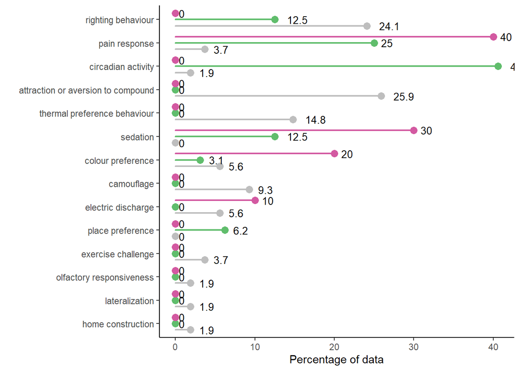

```r
beh_noncat_subcat_fig <- noncat_subcat %>%
    dplyr::mutate(percent_sub_cat = round(percent_sub_cat, 3) * 100) %>%
    ggplot(aes(x = sub_category, y = percent_sub_cat, colour = study_motivation,
        fill = study_motivation, group = study_motivation)) + geom_col(position = position_dodge(width = 0.8),
    width = 0.1) + geom_point(position = position_dodge(width = 0.8), size = 3) +
    geom_text(aes(label = percent_sub_cat), hjust = -0.6, size = 3.5, color = "black",
        position = position_dodge(width = 0.8)) + scale_colour_manual(values = motivation_colour_theme,
    name = "Study motivation") + scale_fill_manual(values = motivation_colour_theme,
    name = "Study motivation") + theme_classic() + coord_flip() + labs(x = "", y = "Percentage of data") +
    theme(legend.position = "none")

beh_noncat_subcat_fig
```

Save the figure

```r
# n_subcat <- noncat_subcat %>% dplyr::distinct(sub_category) %>% nrow(.)/10
# setwd(figures_path) ggsave('beh_noncat_subcat_fig.pdf', plot =
# beh_noncat_subcat_fig, width = 10, height = 11.7*n_subcat)
```

### 10.8.3 Behaviour location

Check where behaviour was measured.

```r
behav_location_summary <- EIPAAB_database %>%
    dplyr::group_by(study_motivation, behav_test_location) %>%
    dplyr::reframe(n = n()) %>%
    tidyr::separate_rows(behav_test_location, sep = ";") %>%
    dplyr::group_by(study_motivation, behav_test_location) %>%
    dplyr::reframe(n = sum(n)) %>%
    tidyr::complete(behav_test_location, study_motivation, fill = list(n = 0)) %>%
    dplyr::group_by(study_motivation) %>%
    dplyr::mutate(total_motivation = sum(n)) %>%
    dplyr::ungroup() %>%
    dplyr::mutate(percent = round(n/total_motivation * 100, 1)) %>%
    dplyr::select(-total_motivation)

behav_location_overall <- behav_location_summary %>%
    dplyr::group_by(behav_test_location) %>%
    dplyr::reframe(n = sum(n)) %>%
    dplyr::mutate(percent = round(n/sum(n) * 100, 1), study_motivation = "Overall")

behav_location_summary <- rbind(behav_location_overall, behav_location_summary) %>%
    dplyr::arrange(study_motivation)

behav_location_summary %>%
    gt()
```

| behav_test_location | n | percent | study_motivation |
| --- | --- | --- | --- |
| indoor laboratory setting or assumed indoors | 363 | 99.7 | Basic research |
| outdoor natural setting | 1 | 0.3 | Basic research |
| outdoor restricted setting (cannot interact with wild species) | 0 | 0.0 | Basic research |
| indoor laboratory setting or assumed indoors | 852 | 98.7 | Environmental |
| outdoor natural setting | 8 | 0.9 | Environmental |
| outdoor restricted setting (cannot interact with wild species) | 3 | 0.3 | Environmental |
| indoor laboratory setting or assumed indoors | 518 | 99.6 | Medical |
| outdoor natural setting | 1 | 0.2 | Medical |
| outdoor restricted setting (cannot interact with wild species) | 1 | 0.2 | Medical |
| indoor laboratory setting or assumed indoors | 1733 | 99.2 | Overall |
| outdoor natural setting | 10 | 0.6 | Overall |
| outdoor restricted setting (cannot interact with wild species) | 4 | 0.2 | Overall |

### 10.8.4 Social context

Check how often behaviour was measured in a social context

```r
behav_social_context_summary <- EIPAAB_database %>%
    dplyr::group_by(study_motivation, behav_is_social_context) %>%
    dplyr::reframe(n = n()) %>%
    dplyr::group_by(study_motivation) %>%
    dplyr::mutate(total_motivation = sum(n)) %>%
    dplyr::ungroup() %>%
    dplyr::mutate(percent = round(n/total_motivation * 100, 1)) %>%
    dplyr::select(-total_motivation)

behav_social_context_overall <- behav_social_context_summary %>%
    dplyr::group_by(behav_is_social_context) %>%
    dplyr::reframe(n = sum(n)) %>%
    dplyr::mutate(percent = round(n/sum(n) * 100, 1), study_motivation = "Overall")

behav_social_context_summary <- rbind(behav_social_context_overall, behav_social_context_summary) %>%
    dplyr::arrange(study_motivation)

behav_social_context_summary %>%
    gt()
```

| behav_is_social_context | n | percent | study_motivation |
| --- | --- | --- | --- |
| no | 287 | 79.1 | Basic research |
| yes | 76 | 20.9 | Basic research |
| no | 634 | 73.9 | Environmental |
| yes | 224 | 26.1 | Environmental |
| no | 443 | 85.5 | Medical |
| yes | 75 | 14.5 | Medical |
| no | 1364 | 78.4 | Overall |
| yes | 375 | 21.6 | Overall |

### 10.8.5 Check how behaviour was meassured

```r
behav_behav_scoring_summary <- EIPAAB_database %>%
    dplyr::group_by(article_id) %>%
    dplyr::sample_n(1) %>%
    dplyr::ungroup() %>%
    dplyr::group_by(study_motivation, validity_behav_scoring_method) %>%
    dplyr::reframe(n = n()) %>%
    tidyr::separate_rows(validity_behav_scoring_method, sep = ";") %>%
    dplyr::group_by(study_motivation, validity_behav_scoring_method) %>%
    dplyr::reframe(n = sum(n)) %>%
    tidyr::complete(validity_behav_scoring_method, study_motivation, fill = list(n = 0)) %>%
    dplyr::group_by(study_motivation) %>%
    dplyr::mutate(total_motivation = sum(n)) %>%
    dplyr::ungroup() %>%
    dplyr::mutate(percent = round(n/total_motivation * 100, 1)) %>%
    dplyr::select(-total_motivation)

behav_behav_scoring_overall <- behav_behav_scoring_summary %>%
    dplyr::group_by(validity_behav_scoring_method) %>%
    dplyr::reframe(n = sum(n)) %>%
    dplyr::mutate(percent = round(n/sum(n) * 100, 1), study_motivation = "Overall")

behav_behav_scoring_summary <- rbind(behav_behav_scoring_overall, behav_behav_scoring_summary) %>%
    dplyr::arrange(study_motivation)
```

```r
behav_behav_scoring_summary %>%
    dplyr::filter(study_motivation == "Overall") %>%
    gt()
```

| validity_behav_scoring_method | n | percent | study_motivation |
| --- | --- | --- | --- |
| acoustic analysis software | 1 | 0.1 | Overall |
| live scoring in real time | 84 | 8.6 | Overall |
| manual or human scoring from videos or image | 259 | 26.6 | Overall |
| not specified | 221 | 22.7 | Overall |
| other | 1 | 0.1 | Overall |
| quantifying food consumption | 21 | 2.2 | Overall |
| sensory for physical movement | 7 | 0.7 | Overall |
| supervised automated tracking approaches | 378 | 38.9 | Overall |

## 10.9 Linking PICO

Making a data frame for a flow diagram (sankey plot)

```r
PICO_df <- EIPAAB_database %>%
    dplyr::mutate(behav_cat = case_when(behav_movement_boolean == 1 ~ "Movement",
        behav_boldness_boolean == 1 ~ "Boldness", behav_foraging_boolean == 1 ~ "Foraging",
        behav_antipredator_boolean == 1 ~ "Antipredator", behav_mating_boolean ==
            1 ~ "Mating", behav_post_mating_boolean == 1 ~ "Post mating", behav_agression_boolean ==
            1 ~ "Agression", behav_sociality_boolean == 1 ~ "Sociality", behav_cognition_boolean ==
            1 ~ "Cognition", behav_noncat_boolean == 1 ~ "Not categorised", )) %>%
    dplyr::select(study_motivation, compound_name, compound_atc_level_3, species_name,
        species_class, behav_cat)
```

Let’s look at the 10 most common classes and ATCs

```r
PICO_class_atc <- PICO_df %>%
    dplyr::filter(!is.na(compound_atc_level_3), !is.na(species_class)) %>%
    tidyr::separate_rows(compound_atc_level_3, sep = ";") %>%
    dplyr::mutate(compound_atc_level_3 = str_trim(compound_atc_level_3))

PICO_atc_10 <- PICO_class_atc %>%
    dplyr::group_by(compound_atc_level_3) %>%
    dplyr::reframe(n = n()) %>%
    dplyr::arrange(desc(n)) %>%
    dplyr::slice(1:10) %>%
    dplyr::pull(compound_atc_level_3)

PICO_class_10 <- PICO_class_atc %>%
    dplyr::group_by(species_class) %>%
    dplyr::reframe(n = n()) %>%
    dplyr::arrange(desc(n)) %>%
    dplyr::slice(1:10) %>%
    dplyr::pull(species_class)

PICO_class_10 <- PICO_class_atc %>%
    dplyr::group_by(species_class) %>%
    dplyr::reframe(n = n()) %>%
    dplyr::arrange(desc(n)) %>%
    dplyr::slice(1:10) %>%
    dplyr::pull(species_class)


behav_cat_order <- PICO_class_atc %>%
    dplyr::filter(compound_atc_level_3 %in% PICO_atc_10 & species_class %in% PICO_class_10) %>%
    dplyr::group_by(behav_cat) %>%
    dplyr::reframe(n = n()) %>%
    dplyr::arrange(desc(n)) %>%
    dplyr::pull(behav_cat)


PICO_class_atc_10 <- PICO_class_atc %>%
    dplyr::filter(compound_atc_level_3 %in% PICO_atc_10 & species_class %in% PICO_class_10) %>%
    dplyr::mutate(compound_atc_level_3 = factor(compound_atc_level_3, levels = PICO_atc_10),
        species_class = factor(species_class, levels = PICO_class_10), behav_cat = factor(behav_cat,
            levels = behav_cat_order)) %>%
    dplyr::select(compound_atc_level_3, behav_cat, species_class)
```

#### 10.9.0.1 Fig 7

```r
PICO_atc_class_sankey <- highcharter::hchart(data_to_sankey(PICO_class_atc_10), "sankey")
PICO_atc_class_sankey
```

[interactive chart not shown]

Save interactive version

```r
# setwd(figures_path) htmlwidgets::saveWidget(widget = PICO_atc_class_sankey,
# file = 'PICO_atc_class_sankey.html')
```

Save static version

```r
# setwd(figures_path) # Make a webshot in pdf : high quality but can not choose
# printed zone webshot::webshot('PICO_atc_class_sankey.html' ,
# 'PICO_atc_class_sankey.pdf', delay = 10)
```

### 10.9.1 Common compounds

Lets take a closer look at the 3 most common compounds

```r
EIPAAB_database %>%
    dplyr::group_by(compound_name) %>%
    dplyr::reframe(n = n()) %>%
    dplyr::arrange(desc(n)) %>%
    dplyr::slice(1:3) %>%
    gt()
```

| compound_name | n |
| --- | --- |
| Fluoxetine | 200 |
| Diazepam | 67 |
| 17-alpha-ethinylestradiol | 63 |

#### 10.9.1.1 Fluoxetine

```r
spp_order <- PICO_df %>%
    dplyr::filter(compound_name == "Fluoxetine") %>%
    dplyr::group_by(species_name) %>%
    dplyr::reframe(n = n()) %>%
    dplyr::arrange(desc(n)) %>%
    dplyr::slice(1:5) %>%
    pull(species_name)

beh_order <- PICO_df %>%
    dplyr::filter(compound_name == "Fluoxetine" & species_name %in% spp_order) %>%
    dplyr::group_by(behav_cat) %>%
    dplyr::reframe(n = n()) %>%
    dplyr::arrange(desc(n)) %>%
    pull(behav_cat)

PICO_fluoxetine <- PICO_df %>%
    dplyr::filter(compound_name == "Fluoxetine" & species_name %in% spp_order) %>%
    dplyr::mutate(species_name = factor(species_name, levels = spp_order), behav_cat = factor(behav_cat,
        levels = beh_order), ) %>%
    dplyr::select(species_name, behav_cat)
```

##### 10.9.1.1.1 Fig S7-1

```r
PICO_fluoxetine_sankey <- highcharter::hchart(data_to_sankey(PICO_fluoxetine), "sankey",
    name = "PICO")
PICO_fluoxetine_sankey
```

[interactive chart not shown]

```r
# setwd(figures_path) htmlwidgets::saveWidget(widget = PICO_fluoxetine_sankey,
# file = 'PICO_fluoxetine_sankey.html')
```

```r
# setwd(figures_path) # Make a webshot in pdf : high quality but can not choose
# printed zone webshot::webshot('PICO_fluoxetine_sankey.html' ,
# 'PICO_fluoxetine_sankey.pdf', delay = 10)
```

#### 10.9.1.2 Diazepam

```r
spp_order <- PICO_df %>%
    dplyr::filter(compound_name == "Diazepam") %>%
    dplyr::group_by(species_name) %>%
    dplyr::reframe(n = n()) %>%
    dplyr::arrange(desc(n)) %>%
    dplyr::slice(1:5) %>%
    pull(species_name)

beh_order <- PICO_df %>%
    dplyr::filter(compound_name == "Diazepam" & species_name %in% spp_order) %>%
    dplyr::group_by(behav_cat) %>%
    dplyr::reframe(n = n()) %>%
    dplyr::arrange(desc(n)) %>%
    pull(behav_cat)

PICO_diazepam <- PICO_df %>%
    dplyr::filter(compound_name == "Diazepam" & species_name %in% spp_order) %>%
    dplyr::mutate(species_name = factor(species_name, levels = spp_order), behav_cat = factor(behav_cat,
        levels = beh_order), ) %>%
    dplyr::select(species_name, behav_cat)
```

##### 10.9.1.2.1 Fig S7-2

```r
PICO_diazepam_sankey <- highcharter::hchart(data_to_sankey(PICO_diazepam), "sankey",
    name = "PICO")
PICO_diazepam_sankey
```

[interactive chart not shown]

Save interactive plot

```r
# setwd(figures_path) htmlwidgets::saveWidget(widget = PICO_diazepam_sankey,
# file = 'PICO_diazepam_sankey.html')
```

Save static plot

```r
# setwd(figures_path) Make a webshot in pdf : high quality but can not choose
# printed zone webshot::webshot('PICO_diazepam_sankey.html' ,
# 'PICO_diazepam_sankey.pdf', delay = 10)
```

#### 10.9.1.3 17-alpha-ethinylestradiol

```r
spp_order <- PICO_df %>%
    dplyr::filter(compound_name == "17-alpha-ethinylestradiol") %>%
    dplyr::group_by(species_name) %>%
    dplyr::reframe(n = n()) %>%
    dplyr::arrange(desc(n)) %>%
    dplyr::slice(1:5) %>%
    pull(species_name)

beh_order <- PICO_df %>%
    dplyr::filter(compound_name == "17-alpha-ethinylestradiol" & species_name %in%
        spp_order) %>%
    dplyr::group_by(behav_cat) %>%
    dplyr::reframe(n = n()) %>%
    dplyr::arrange(desc(n)) %>%
    pull(behav_cat)

PICO_EE2 <- PICO_df %>%
    dplyr::filter(compound_name == "17-alpha-ethinylestradiol" & species_name %in%
        spp_order) %>%
    dplyr::mutate(species_name = factor(species_name, levels = spp_order), behav_cat = factor(behav_cat,
        levels = beh_order), ) %>%
    dplyr::select(species_name, behav_cat)
```

##### 10.9.1.3.1 Fig S7-3

```r
PICO_EE2_sankey <- highcharter::hchart(data_to_sankey(PICO_EE2), "sankey", name = "PICO")
PICO_EE2_sankey
```

[interactive chart not shown]

Save interactive plot

```r
# setwd(figures_path) htmlwidgets::saveWidget(widget = PICO_EE2_sankey, file =
# 'PICO_EE2_sankey.html')
```

Save static plot

```r
# setwd(figures_path) #Make a webshot in pdf : high quality but can not choose
# printed zone webshot::webshot('PICO_EE2_sankey.html' , 'PICO_EE2_sankey.pdf',
# delay = 10)
```

## 10.10 Knowledge clusters and gaps

Identify knowledge clusters and gaps.

We will also do this by study motivation, because the knowledge gaps will be motivation specific.

### 10.10.1 Species class

First look by species class

Making a data frame

```r
behav_cat_class_long <- PICO_df %>%
    dplyr::group_by(study_motivation, species_class, behav_cat) %>%
    dplyr::reframe(count = n()) %>%
    tidyr::complete(study_motivation, species_class, behav_cat, fill = list(count = 0)) %>%
    dplyr::group_by(study_motivation, species_class) %>%
    dplyr::mutate(total_class_motivation = sum(count)) %>%
    dplyr::ungroup() %>%
    dplyr::mutate(rel_percent = round(count/total_class_motivation * 100, 0), rel_percent = if_else(is.finite(rel_percent),
        rel_percent, 0))

class_order <- behav_cat_class_long %>%
    dplyr::group_by(species_class) %>%
    dplyr::reframe(n = sum(count)) %>%
    dplyr::arrange(n) %>%
    dplyr::pull(species_class)

behav_cat_order <- behav_cat_class_long %>%
    dplyr::group_by(behav_cat) %>%
    dplyr::reframe(n = sum(count)) %>%
    dplyr::arrange(desc(n)) %>%
    dplyr::pull(behav_cat)

behav_cat_class_long <- behav_cat_class_long %>%
    dplyr::mutate(species_class = factor(species_class, levels = class_order), behav_cat = factor(behav_cat,
        levels = behav_cat_order))
```

Creating a tile plot

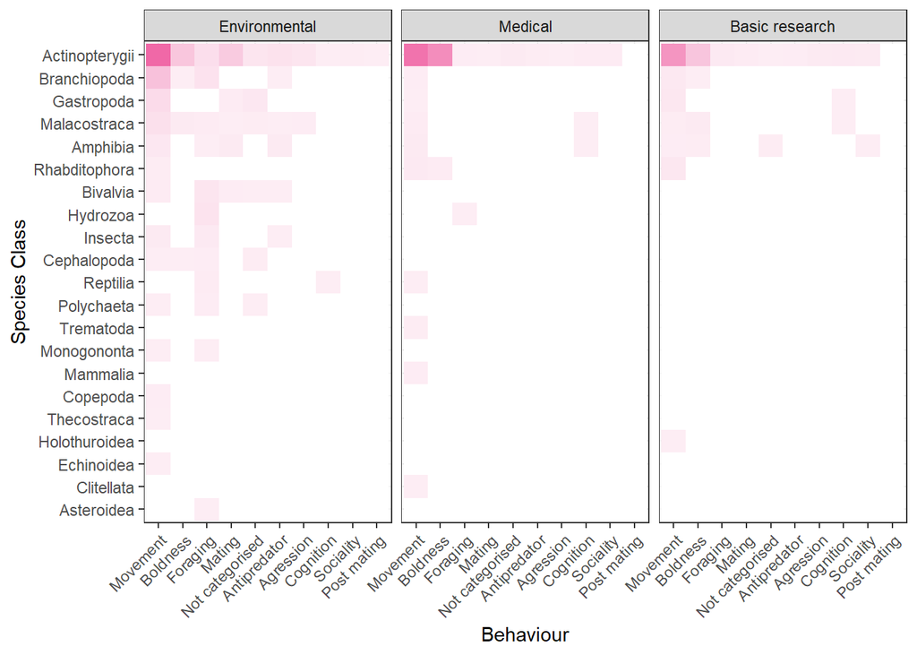

```r
cust_col <- colorRampPalette(c("#FDEDF4", "#F068A7"))(30)

behav_class_hm <- behav_cat_class_long %>%
    ggplot(aes(x = behav_cat, y = species_class, fill = count)) + geom_tile() + scale_fill_gradientn(colors = cust_col,
    na.value = "white", limits = c(1, max(behav_cat_class_long$count, na.rm = TRUE)),
    guide = "none") + theme_bw() + facet_wrap(~study_motivation) + theme(axis.text.x = element_text(angle = 45,
    hjust = 1)) + labs(x = "Behaviour", y = "Species Class", fill = "Count")
behav_class_hm
```

```r
# setwd(figures_path) ggsave('behav_class_hm.pdf', plot = behav_class_hm, width
# = 8.3, height = 11.7/2)
```

This one uses relative vaules for each class (e.g. row in the heat map)

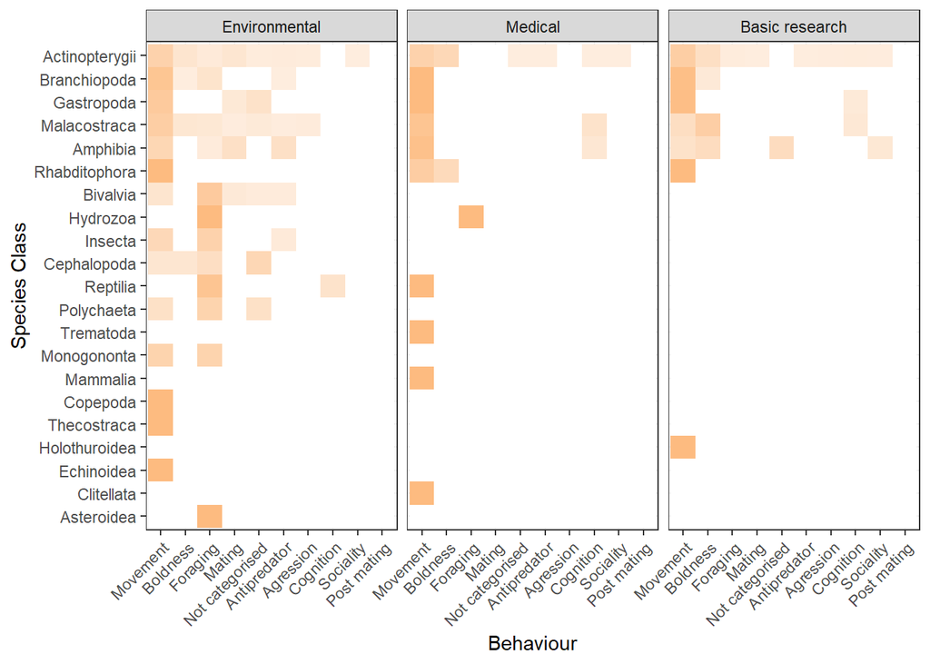

```r
cust_col <- colorRampPalette(brewer.pal(4, "Oranges"))(30)

behav_class_rel_hm <- behav_cat_class_long %>%
    ggplot(aes(x = behav_cat, y = species_class, fill = rel_percent)) + geom_tile() +
    # geom_text(aes(label = ifelse(rel_percent == 0, NA, rel_percent)), color =
    # 'black', size = 3) +
scale_fill_gradientn(colors = cust_col, na.value = "white", limits = c(1, max(behav_cat_class_long$count,
    na.rm = TRUE)), guide = "none") + theme_bw() + facet_wrap(~study_motivation) +
    theme(axis.text.x = element_text(angle = 45, hjust = 1)) + labs(x = "Behaviour",
    y = "Species Class", fill = "Count")
behav_class_rel_hm
```

```r
# setwd(figures_path) ggsave('behav_class_rel_hm.pdf', plot =
# behav_class_rel_hm, width = 8.3, height = 11.7/2)
```

### 10.10.2 Compound cluster/gaps

Now looking by compound

Making a data frame

```r
behav_atc_long <- PICO_df %>%
    separate_rows(compound_atc_level_3, sep = ";") %>%
    dplyr::group_by(study_motivation, compound_atc_level_3, behav_cat) %>%
    dplyr::reframe(count = n()) %>%
    tidyr::complete(study_motivation, compound_atc_level_3, behav_cat, fill = list(count = 0)) %>%
    dplyr::group_by(study_motivation, compound_atc_level_3) %>%
    dplyr::mutate(total_atc_motivation = sum(count)) %>%
    dplyr::ungroup() %>%
    dplyr::mutate(rel_percent = round(count/total_atc_motivation * 100, 0), rel_percent = if_else(is.finite(rel_percent),
        rel_percent, 0))

atc_order <- behav_atc_long %>%
    dplyr::group_by(compound_atc_level_3) %>%
    dplyr::reframe(n = sum(count)) %>%
    dplyr::arrange(n) %>%
    dplyr::pull(compound_atc_level_3)

behav_cat_order <- behav_atc_long %>%
    dplyr::group_by(behav_cat) %>%
    dplyr::reframe(n = sum(count)) %>%
    dplyr::arrange(desc(n)) %>%
    dplyr::pull(behav_cat)

behav_atc_long <- behav_atc_long %>%
    dplyr::mutate(compound_atc_level_3 = factor(compound_atc_level_3, levels = atc_order),
        behav_cat = factor(behav_cat, levels = behav_cat_order))
```

There are 132 ATC level 3 codes. So a tile plot is not going to be very informative. It could be useful if you are only interested in a few ATC groups.

```r
behav_atc_long %>%
    dplyr::distinct(compound_atc_level_3) %>%
    nrow()
```

```
## [1] 132
```

Code for title plot if you would like to make one.

```r
# cust_col <- colorRampPalette(c('#FDEDF4', '#F068A7'))(30) behav_atc_hm <-
# behav_atc_long %>% ggplot(aes(x = behav_cat, y = compound_atc_level_3, fill =
# count)) + geom_tile() + #geom_text(aes(label = ifelse(count == 0, NA,
# count)), color = 'black', size = 3) + scale_fill_gradientn(colors = cust_col,
# na.value = 'white', limits = c(1, max(behav_atc_long$count, na.rm = TRUE)),
# guide = 'none') + theme_void() + facet_wrap(~study_motivation) +
# theme(axis.text.x = element_text(angle = 45, hjust = 1)) + labs( x =
# 'Behaviour', y = 'Species Class', fill = 'Count' ) behav_atc_hm
```

Save figure

```r
# setwd(figures_path) ggsave('behav_atc_hm.pdf', plot = behav_atc_hm, width =
# 8.3, height = 11.7/2)
```

## 10.11 Additional biomarkers

How many meassured addtional biomarks

```r
EIPAAB_database %>%
    dplyr::group_by(article_id) %>%
    dplyr::sample_n(1) %>%
    dplyr::group_by(additional_biomarkers) %>%
    dplyr::reframe(n = n()) %>%
    dplyr::mutate(total = sum(n), percent = n/total) %>%
    gt()
```

| additional_biomarkers | n | total | percent |
| --- | --- | --- | --- |
| No | 435 | 901 | 0.4827969 |
| Yes | 466 | 901 | 0.5172031 |

How many measured survival/growth/reproduction

```r
EIPAAB_database %>%
    dplyr::group_by(article_id) %>%
    dplyr::sample_n(1) %>%
    dplyr::group_by(validity_survival_growth_reproduction) %>%
    dplyr::reframe(n = n()) %>%
    dplyr::mutate(total = sum(n), percent = n/total) %>%
    gt()
```

| validity_survival_growth_reproduction | n | total | percent |
| --- | --- | --- | --- |
| No | 543 | 901 | 0.6026637 |
| Yes | 358 | 901 | 0.3973363 |

## 10.12 Validity

There are 19 metadata columns relating to validty: “validity_guideline”, “validity_good_laboratory_practice”, “validity_survival_growth_reproduction”, “validity_animal_feeding”, “validity_water_quality”, “validity_light_cycle”, “validity_randomization”, “validity_behav_scoring_method”, “validity_behav_blinding”, “validity_conflict_statement”, “species_source”, “species_stage”, “species_sex”, “compound_min_duration_exposure”, “compound_max_duration_exposure”, “validity_compound_cas_reported”, “validity_compound_purity_reported”, “validity_compound_water_verification”, “validity_compound_animal_verification”.

### 10.12.1 Did it follow a guideline (CRED Q1)

```r
guideline <- EIPAAB_database %>%
    dplyr::group_by(article_id) %>%
    dplyr::sample_n(1) %>%
    dplyr::ungroup() %>%
    dplyr::group_by(validity_guideline, study_motivation) %>%
    dplyr::reframe(n = n()) %>%
    dplyr::group_by(study_motivation) %>%
    dplyr::mutate(total_motivation = sum(n)) %>%
    dplyr::ungroup() %>%
    dplyr::mutate(percent = round(n/total_motivation * 100, 1)) %>%
    dplyr::select(-total_motivation)

guideline_all <- guideline %>%
    dplyr::group_by(validity_guideline) %>%
    dplyr::reframe(n = sum(n)) %>%
    dplyr::mutate(study_motivation = "Overall", percent = round(n/sum(n) * 100, 1))


guideline_all <- rbind(guideline_all, guideline) %>%
    dplyr::filter(validity_guideline == "Yes")
guideline_all %>%
    gt()
```

| validity_guideline | n | study_motivation | percent |
| --- | --- | --- | --- |
| Yes | 135 | Overall | 15.0 |
| Yes | 111 | Environmental | 21.8 |
| Yes | 14 | Medical | 6.0 |
| Yes | 10 | Basic research | 6.3 |

### 10.12.2 Did it use good laboratory practice (CRED Q2)

```r
GLP <- EIPAAB_database %>%
    dplyr::group_by(article_id) %>%
    dplyr::sample_n(1) %>%
    dplyr::ungroup() %>%
    dplyr::group_by(validity_good_laboratory_practice, study_motivation) %>%
    dplyr::reframe(n = n()) %>%
    dplyr::group_by(study_motivation) %>%
    dplyr::mutate(total_motivation = sum(n)) %>%
    dplyr::ungroup() %>%
    dplyr::mutate(percent = round(n/total_motivation * 100, 1)) %>%
    dplyr::select(-total_motivation)

GLP_all <- GLP %>%
    dplyr::group_by(validity_good_laboratory_practice) %>%
    dplyr::reframe(n = sum(n)) %>%
    dplyr::mutate(study_motivation = "Overall", percent = round(n/sum(n) * 100, 1))


GLP_all <- rbind(GLP_all, GLP) %>%
    dplyr::filter(validity_good_laboratory_practice == "Yes")
GLP_all %>%
    gt()
```

| validity_good_laboratory_practice | n | study_motivation | percent |
| --- | --- | --- | --- |
| Yes | 6 | Overall | 0.7 |
| Yes | 5 | Environmental | 1.0 |
| Yes | 1 | Medical | 0.4 |

### 10.12.3 Did it report survival, growth and/or reproduction (CRED Q3)

```r
survival_growth_reproduction <- EIPAAB_database %>%
    dplyr::group_by(article_id) %>%
    dplyr::sample_n(1) %>%
    dplyr::ungroup() %>%
    dplyr::group_by(validity_survival_growth_reproduction, study_motivation) %>%
    dplyr::reframe(n = n()) %>%
    dplyr::group_by(study_motivation) %>%
    dplyr::mutate(total_motivation = sum(n)) %>%
    dplyr::ungroup() %>%
    dplyr::mutate(percent = round(n/total_motivation * 100, 1)) %>%
    dplyr::select(-total_motivation)

survival_growth_reproduction_all <- survival_growth_reproduction %>%
    dplyr::group_by(validity_survival_growth_reproduction) %>%
    dplyr::reframe(n = sum(n)) %>%
    dplyr::mutate(study_motivation = "Overall", percent = round(n/sum(n) * 100, 1))


survival_growth_reproduction_all <- rbind(survival_growth_reproduction_all, survival_growth_reproduction) %>%
    dplyr::filter(validity_survival_growth_reproduction == "Yes")
survival_growth_reproduction_all %>%
    gt()
```

| validity_survival_growth_reproduction | n | study_motivation | percent |
| --- | --- | --- | --- |
| Yes | 358 | Overall | 39.7 |
| Yes | 273 | Environmental | 53.5 |
| Yes | 61 | Medical | 26.2 |
| Yes | 24 | Basic research | 15.2 |

### 10.12.4 Did it report compound cas (CRED Q5)

```r
CAS <- EIPAAB_database %>%
    dplyr::group_by(article_id) %>%
    dplyr::sample_n(1) %>%
    dplyr::ungroup() %>%
    dplyr::group_by(validity_compound_cas_reported, study_motivation) %>%
    dplyr::reframe(n = n()) %>%
    dplyr::group_by(study_motivation) %>%
    dplyr::mutate(total_motivation = sum(n)) %>%
    dplyr::ungroup() %>%
    dplyr::mutate(percent = round(n/total_motivation * 100, 1)) %>%
    dplyr::select(-total_motivation)

CAS_all <- CAS %>%
    dplyr::group_by(validity_compound_cas_reported) %>%
    dplyr::reframe(n = sum(n)) %>%
    dplyr::mutate(study_motivation = "Overall", percent = round(n/sum(n) * 100, 1))


CAS_all <- rbind(CAS_all, CAS) %>%
    dplyr::filter(validity_compound_cas_reported == "Yes")
CAS_all %>%
    gt()
```

| validity_compound_cas_reported | n | study_motivation | percent |
| --- | --- | --- | --- |
| Yes | 223 | Overall | 24.8 |
| Yes | 187 | Environmental | 36.7 |
| Yes | 25 | Medical | 10.7 |
| Yes | 11 | Basic research | 7.0 |

### 10.12.5 Did it report compound purity (CRED Q6)

```r
purity <- EIPAAB_database %>%
    dplyr::group_by(article_id) %>%
    dplyr::sample_n(1) %>%
    dplyr::ungroup() %>%
    dplyr::group_by(validity_compound_purity_reported, study_motivation) %>%
    dplyr::reframe(n = n()) %>%
    dplyr::group_by(study_motivation) %>%
    dplyr::mutate(total_motivation = sum(n)) %>%
    dplyr::ungroup() %>%
    dplyr::mutate(percent = round(n/total_motivation * 100, 1)) %>%
    dplyr::select(-total_motivation)

purity_all <- purity %>%
    dplyr::group_by(validity_compound_purity_reported) %>%
    dplyr::reframe(n = sum(n)) %>%
    dplyr::mutate(study_motivation = "Overall", percent = round(n/sum(n) * 100, 1))


purity_all <- rbind(purity_all, purity) %>%
    dplyr::filter(validity_compound_purity_reported == "Yes")
purity_all %>%
    gt()
```

| validity_compound_purity_reported | n | study_motivation | percent |
| --- | --- | --- | --- |
| Yes | 229 | Overall | 25.4 |
| Yes | 200 | Environmental | 39.2 |
| Yes | 20 | Medical | 8.6 |
| Yes | 9 | Basic research | 5.7 |

### 10.12.6 Species infomartion (CRED Q8)

#### 10.12.6.1 Life stage

```r
stage <- EIPAAB_database %>%
    dplyr::group_by(unique_population_id) %>%
    dplyr::sample_n(1) %>%
    dplyr::ungroup() %>%
    dplyr::group_by(species_stage, study_motivation) %>%
    dplyr::reframe(n = n()) %>%
    tidyr::separate_rows(species_stage, sep = ";") %>%
    dplyr::group_by(species_stage, study_motivation) %>%
    dplyr::reframe(n = sum(n)) %>%
    dplyr::group_by(study_motivation) %>%
    dplyr::mutate(total_motivation = sum(n)) %>%
    dplyr::ungroup() %>%
    dplyr::mutate(percent = round(n/total_motivation * 100, 1)) %>%
    dplyr::select(-total_motivation)

stage_all <- stage %>%
    dplyr::group_by(species_stage) %>%
    dplyr::reframe(n = sum(n)) %>%
    dplyr::mutate(study_motivation = "Overall", percent = round(n/sum(n) * 100, 1))


stage_all <- rbind(stage_all, stage) %>%
    dplyr::filter(species_stage == "Unknown or not specified") %>%
    dplyr::mutate(percent_reported = 100 - percent)
stage_all %>%
    gt()
```

| species_stage | n | study_motivation | percent | percent_reported |
| --- | --- | --- | --- | --- |
| Unknown or not specified | 166 | Overall | 16.6 | 83.4 |
| Unknown or not specified | 100 | Environmental | 17.1 | 82.9 |
| Unknown or not specified | 22 | Medical | 9.0 | 91.0 |
| Unknown or not specified | 44 | Basic research | 26.5 | 73.5 |

#### 10.12.6.2 Sex

```r
sex <- EIPAAB_database %>%
    dplyr::group_by(unique_population_id) %>%
    dplyr::sample_n(1) %>%
    dplyr::ungroup() %>%
    dplyr::group_by(species_sex, study_motivation) %>%
    dplyr::reframe(n = n()) %>%
    tidyr::separate_rows(species_sex, sep = ";") %>%
    dplyr::group_by(species_sex, study_motivation) %>%
    dplyr::reframe(n = sum(n)) %>%
    dplyr::group_by(study_motivation) %>%
    dplyr::mutate(total_motivation = sum(n)) %>%
    dplyr::ungroup() %>%
    dplyr::mutate(percent = round(n/total_motivation * 100, 1)) %>%
    dplyr::select(-total_motivation)

sex_all <- sex %>%
    dplyr::group_by(species_sex) %>%
    dplyr::reframe(n = sum(n)) %>%
    dplyr::mutate(study_motivation = "Overall", percent = round(n/sum(n) * 100, 1))


sex_all <- rbind(sex_all, sex) %>%
    dplyr::filter(species_sex == "Unknown or not specified") %>%
    dplyr::mutate(percent_reported = 100 - percent)
sex_all %>%
    gt()
```

| species_sex | n | study_motivation | percent | percent_reported |
| --- | --- | --- | --- | --- |
| Unknown or not specified | 546 | Overall | 46.5 | 53.5 |
| Unknown or not specified | 325 | Environmental | 50.4 | 49.6 |
| Unknown or not specified | 132 | Medical | 41.0 | 59.0 |
| Unknown or not specified | 89 | Basic research | 43.2 | 56.8 |

### 10.12.7 The soruce of species (CRED Q9)

```r
source <- EIPAAB_database %>%
    dplyr::group_by(unique_population_id) %>%
    dplyr::sample_n(1) %>%
    dplyr::ungroup() %>%
    dplyr::group_by(species_source, study_motivation) %>%
    dplyr::reframe(n = n()) %>%
    tidyr::separate_rows(species_source, sep = ";") %>%
    dplyr::group_by(species_source, study_motivation) %>%
    dplyr::reframe(n = sum(n)) %>%
    dplyr::group_by(study_motivation) %>%
    dplyr::mutate(total_motivation = sum(n)) %>%
    dplyr::ungroup() %>%
    dplyr::mutate(percent = round(n/total_motivation * 100, 1)) %>%
    dplyr::select(-total_motivation)

source_all <- source %>%
    dplyr::group_by(species_source) %>%
    dplyr::reframe(n = sum(n)) %>%
    dplyr::mutate(study_motivation = "Overall", percent = round(n/sum(n) * 100, 1))


source_all <- rbind(source_all, source) %>%
    dplyr::filter(species_source == "Not reported") %>%
    dplyr::mutate(percent_reported = 100 - percent)
source_all %>%
    gt()
```

| species_source | n | study_motivation | percent | percent_reported |
| --- | --- | --- | --- | --- |
| Not reported | 148 | Overall | 15.6 | 84.4 |
| Not reported | 72 | Environmental | 13.1 | 86.9 |
| Not reported | 51 | Medical | 21.2 | 78.8 |
| Not reported | 25 | Basic research | 15.4 | 84.6 |

### 10.12.8 experimental system (CRED Q11)

#### 10.12.8.1 Feeding

```r
feeding <- EIPAAB_database %>%
    dplyr::group_by(article_id) %>%
    dplyr::sample_n(1) %>%
    dplyr::ungroup() %>%
    dplyr::group_by(validity_animal_feeding, study_motivation) %>%
    dplyr::reframe(n = n()) %>%
    dplyr::group_by(study_motivation) %>%
    dplyr::mutate(total_motivation = sum(n)) %>%
    dplyr::ungroup() %>%
    dplyr::mutate(percent = round(n/total_motivation * 100, 1)) %>%
    dplyr::select(-total_motivation)

feeding_all <- feeding %>%
    dplyr::group_by(validity_animal_feeding) %>%
    dplyr::reframe(n = sum(n)) %>%
    dplyr::mutate(study_motivation = "Overall", percent = round(n/sum(n) * 100, 1))


feeding_all <- rbind(feeding_all, feeding) %>%
    dplyr::filter(validity_animal_feeding == "Yes")
feeding_all %>%
    gt()
```

| validity_animal_feeding | n | study_motivation | percent |
| --- | --- | --- | --- |
| Yes | 716 | Overall | 79.5 |
| Yes | 430 | Environmental | 84.3 |
| Yes | 159 | Medical | 68.2 |
| Yes | 127 | Basic research | 80.4 |

#### 10.12.8.2 Water quality

```r
water <- EIPAAB_database %>%
    dplyr::group_by(article_id) %>%
    dplyr::sample_n(1) %>%
    dplyr::ungroup() %>%
    dplyr::group_by(validity_water_quality, study_motivation) %>%
    dplyr::reframe(n = n()) %>%
    dplyr::group_by(study_motivation) %>%
    dplyr::mutate(total_motivation = sum(n)) %>%
    dplyr::ungroup() %>%
    dplyr::mutate(percent = round(n/total_motivation * 100, 1)) %>%
    dplyr::select(-total_motivation)

water_all <- water %>%
    dplyr::group_by(validity_water_quality) %>%
    dplyr::reframe(n = sum(n)) %>%
    dplyr::mutate(study_motivation = "Overall", percent = round(n/sum(n) * 100, 1))


water_all <- rbind(water_all, water) %>%
    dplyr::filter(validity_water_quality == "Yes")
water_all %>%
    gt()
```

| validity_water_quality | n | study_motivation | percent |
| --- | --- | --- | --- |
| Yes | 806 | Overall | 89.5 |
| Yes | 473 | Environmental | 92.7 |
| Yes | 206 | Medical | 88.4 |
| Yes | 127 | Basic research | 80.4 |

#### 10.12.8.3 light cycle

```r
light <- EIPAAB_database %>%
    dplyr::group_by(article_id) %>%
    dplyr::sample_n(1) %>%
    dplyr::ungroup() %>%
    dplyr::group_by(validity_light_cycle, study_motivation) %>%
    dplyr::reframe(n = n()) %>%
    dplyr::group_by(study_motivation) %>%
    dplyr::mutate(total_motivation = sum(n)) %>%
    dplyr::ungroup() %>%
    dplyr::mutate(percent = round(n/total_motivation * 100, 1)) %>%
    dplyr::select(-total_motivation)

light_all <- light %>%
    dplyr::group_by(validity_light_cycle) %>%
    dplyr::reframe(n = sum(n)) %>%
    dplyr::mutate(study_motivation = "Overall", percent = round(n/sum(n) * 100, 1))


light_all <- rbind(light_all, light) %>%
    dplyr::filter(validity_light_cycle == "Yes")
light_all %>%
    gt()
```

| validity_light_cycle | n | study_motivation | percent |
| --- | --- | --- | --- |
| Yes | 756 | Overall | 83.9 |
| Yes | 429 | Environmental | 84.1 |
| Yes | 200 | Medical | 85.8 |
| Yes | 127 | Basic research | 80.4 |

### 10.12.9 Exposure duration (CRED Q14)

#### 10.12.9.1 Minimum duration

```r
min_duration <- EIPAAB_database %>%
    dplyr::group_by(compound_min_duration_exposure, study_motivation) %>%
    dplyr::reframe(n = n()) %>%
    dplyr::group_by(study_motivation) %>%
    dplyr::mutate(total_motivation = sum(n)) %>%
    dplyr::ungroup() %>%
    dplyr::mutate(percent = round(n/total_motivation * 100, 1)) %>%
    dplyr::select(-total_motivation)

min_duration_all <- min_duration %>%
    dplyr::group_by(compound_min_duration_exposure) %>%
    dplyr::reframe(n = sum(n)) %>%
    dplyr::mutate(study_motivation = "Overall", percent = round(n/sum(n) * 100, 1))


min_duration_all <- rbind(min_duration_all, min_duration) %>%
    dplyr::filter(compound_min_duration_exposure == "Not stated") %>%
    dplyr::mutate(percent_reported = 100 - percent)
min_duration_all %>%
    gt()
```

| compound_min_duration_exposure | n | study_motivation | percent | percent_reported |
| --- | --- | --- | --- | --- |
| Not stated | 102 | Overall | 5.9 | 94.1 |
| Not stated | 38 | Environmental | 4.4 | 95.6 |
| Not stated | 52 | Medical | 10.0 | 90.0 |
| Not stated | 12 | Basic research | 3.3 | 96.7 |

### 10.12.10 Maximum duration

```r
max_duration <- EIPAAB_database %>%
    dplyr::group_by(compound_max_duration_exposure, study_motivation) %>%
    dplyr::reframe(n = n()) %>%
    dplyr::group_by(study_motivation) %>%
    dplyr::mutate(total_motivation = sum(n)) %>%
    dplyr::ungroup() %>%
    dplyr::mutate(percent = round(n/total_motivation * 100, 1)) %>%
    dplyr::select(-total_motivation)

max_duration_all <- max_duration %>%
    dplyr::group_by(compound_max_duration_exposure) %>%
    dplyr::reframe(n = sum(n)) %>%
    dplyr::mutate(study_motivation = "Overall", percent = round(n/sum(n) * 100, 1))


max_duration_all <- rbind(max_duration_all, max_duration) %>%
    dplyr::filter(compound_max_duration_exposure == "Not stated") %>%
    dplyr::mutate(percent_reported = 100 - percent)
max_duration_all %>%
    gt()
```

| compound_max_duration_exposure | n | study_motivation | percent | percent_reported |
| --- | --- | --- | --- | --- |
| Not stated | 96 | Overall | 5.5 | 94.5 |
| Not stated | 32 | Environmental | 3.7 | 96.3 |
| Not stated | 53 | Medical | 10.2 | 89.8 |
| Not stated | 11 | Basic research | 3.0 | 97.0 |

### 10.12.11 Exposure verification (CRED Q15)

#### 10.12.11.1 Water verification

```r
water_verification <- EIPAAB_database %>%
    dplyr::filter(!is.na(validity_compound_water_verification)) %>%
    dplyr::group_by(validity_compound_water_verification, study_motivation) %>%
    dplyr::reframe(n = n()) %>%
    dplyr::group_by(study_motivation) %>%
    dplyr::mutate(total_motivation = sum(n)) %>%
    dplyr::ungroup() %>%
    dplyr::mutate(percent = round(n/total_motivation * 100, 1)) %>%
    dplyr::select(-total_motivation)

water_verification_all <- water_verification %>%
    dplyr::group_by(validity_compound_water_verification) %>%
    dplyr::reframe(n = sum(n)) %>%
    dplyr::mutate(study_motivation = "Overall", percent = round(n/sum(n) * 100, 1))


water_verification_all <- rbind(water_verification_all, water_verification) %>%
    dplyr::filter(validity_compound_water_verification == "Measured")
water_verification_all %>%
    gt()
```

| validity_compound_water_verification | n | study_motivation | percent |
| --- | --- | --- | --- |
| Measured | 313 | Overall | 20.6 |
| Measured | 295 | Environmental | 35.8 |
| Measured | 10 | Medical | 2.5 |
| Measured | 8 | Basic research | 2.7 |

#### 10.12.11.2 Tissue verification

```r
tissue_verification <- EIPAAB_database %>%
    # dplyr::filter(!is.na(validity_compound_animal_verification)) %>%
dplyr::group_by(validity_compound_animal_verification, study_motivation) %>%
    dplyr::reframe(n = n()) %>%
    dplyr::group_by(study_motivation) %>%
    dplyr::mutate(total_motivation = sum(n)) %>%
    dplyr::ungroup() %>%
    dplyr::mutate(percent = round(n/total_motivation * 100, 1)) %>%
    dplyr::select(-total_motivation)

tissue_verification_all <- tissue_verification %>%
    dplyr::group_by(validity_compound_animal_verification) %>%
    dplyr::reframe(n = sum(n)) %>%
    dplyr::mutate(study_motivation = "Overall", percent = round(n/sum(n) * 100, 1))


tissue_verification_all <- rbind(tissue_verification_all, tissue_verification) %>%
    dplyr::filter(validity_compound_animal_verification == "Yes")
tissue_verification_all %>%
    gt()
```

| validity_compound_animal_verification | n | study_motivation | percent |
| --- | --- | --- | --- |
| Yes | 154 | Overall | 8.9 |
| Yes | 115 | Environmental | 13.4 |
| Yes | 22 | Medical | 4.2 |
| Yes | 17 | Basic research | 4.7 |

### 10.12.12 Randomization (Not CRED)

```r
randomization <- EIPAAB_database %>%
    dplyr::group_by(article_id) %>%
    dplyr::sample_n(1) %>%
    dplyr::ungroup() %>%
    dplyr::group_by(validity_randomization, study_motivation) %>%
    dplyr::reframe(n = n()) %>%
    dplyr::group_by(study_motivation) %>%
    dplyr::mutate(total_motivation = sum(n)) %>%
    dplyr::ungroup() %>%
    dplyr::mutate(percent = round(n/total_motivation * 100, 1)) %>%
    dplyr::select(-total_motivation)

randomization_all <- randomization %>%
    dplyr::group_by(validity_randomization) %>%
    dplyr::reframe(n = sum(n)) %>%
    dplyr::mutate(study_motivation = "Overall", percent = round(n/sum(n) * 100, 1))


randomization_all <- rbind(randomization_all, randomization) %>%
    dplyr::filter(validity_randomization == "Yes") %>%
    dplyr::mutate(percent_disclosed = 100 - percent)
randomization_all %>%
    gt()
```

| validity_randomization | n | study_motivation | percent | percent_disclosed |
| --- | --- | --- | --- | --- |
| Yes | 362 | Overall | 40.2 | 59.8 |
| Yes | 229 | Environmental | 44.9 | 55.1 |
| Yes | 75 | Medical | 32.2 | 67.8 |
| Yes | 58 | Basic research | 36.7 | 63.3 |

### 10.12.13 Blinding (Not CRED)

```r
blinding <- EIPAAB_database %>%
    dplyr::group_by(article_id) %>%
    dplyr::sample_n(1) %>%
    dplyr::ungroup() %>%
    dplyr::group_by(validity_behav_blinding, study_motivation) %>%
    dplyr::reframe(n = n()) %>%
    dplyr::group_by(study_motivation) %>%
    dplyr::mutate(total_motivation = sum(n)) %>%
    dplyr::ungroup() %>%
    dplyr::mutate(percent = round(n/total_motivation * 100, 1)) %>%
    dplyr::select(-total_motivation)

blinding_all <- blinding %>%
    dplyr::group_by(validity_behav_blinding) %>%
    dplyr::reframe(n = sum(n)) %>%
    dplyr::mutate(study_motivation = "Overall", percent = round(n/sum(n) * 100, 1))


blinding_all <- rbind(blinding_all, blinding) %>%
    dplyr::filter(validity_behav_blinding == "Yes")
blinding_all %>%
    gt()
```

| validity_behav_blinding | n | study_motivation | percent |
| --- | --- | --- | --- |
| Yes | 153 | Overall | 17.0 |
| Yes | 75 | Environmental | 14.7 |
| Yes | 44 | Medical | 18.9 |
| Yes | 34 | Basic research | 21.5 |

### 10.12.14 Scoring method (Not CRED)

```r
behav_scoring <- EIPAAB_database %>%
    dplyr::group_by(article_id) %>%
    dplyr::sample_n(1) %>%
    dplyr::ungroup() %>%
    tidyr::separate_rows(validity_behav_scoring_method, sep = ";") %>%
    dplyr::group_by(validity_behav_scoring_method, study_motivation) %>%
    dplyr::reframe(n = n()) %>%
    dplyr::group_by(study_motivation) %>%
    dplyr::mutate(total_motivation = sum(n)) %>%
    dplyr::ungroup() %>%
    dplyr::mutate(percent = round(n/total_motivation * 100, 1)) %>%
    dplyr::select(-total_motivation)

behav_scoring_all <- behav_scoring %>%
    dplyr::group_by(validity_behav_scoring_method) %>%
    dplyr::reframe(n = sum(n)) %>%
    dplyr::mutate(study_motivation = "Overall", percent = round(n/sum(n) * 100, 1))


behav_scoring_all <- rbind(behav_scoring_all, behav_scoring) %>%
    dplyr::filter(validity_behav_scoring_method == "not specified") %>%
    dplyr::mutate(percent_specified = 100 - percent)
behav_scoring_all %>%
    gt()
```

| validity_behav_scoring_method | n | study_motivation | percent | percent_specified |
| --- | --- | --- | --- | --- |
| not specified | 221 | Overall | 22.7 | 77.3 |
| not specified | 130 | Environmental | 24.0 | 76.0 |
| not specified | 56 | Medical | 21.5 | 78.5 |
| not specified | 35 | Basic research | 20.6 | 79.4 |

### 10.12.15 Conflict statement (Not CRED)

```r
conflict <- EIPAAB_database %>%
    dplyr::group_by(article_id) %>%
    dplyr::sample_n(1) %>%
    dplyr::ungroup() %>%
    dplyr::group_by(validity_conflict_statement, study_motivation) %>%
    dplyr::reframe(n = n()) %>%
    dplyr::group_by(study_motivation) %>%
    dplyr::mutate(total_motivation = sum(n)) %>%
    dplyr::ungroup() %>%
    dplyr::mutate(percent = round(n/total_motivation * 100, 1)) %>%
    dplyr::select(-total_motivation)

conflict_all <- conflict %>%
    dplyr::group_by(validity_conflict_statement) %>%
    dplyr::reframe(n = sum(n)) %>%
    dplyr::mutate(study_motivation = "Overall", percent = round(n/sum(n) * 100, 1))


conflict_all <- rbind(conflict_all, conflict) %>%
    dplyr::filter(validity_conflict_statement == "No statement is made in the paper") %>%
    dplyr::mutate(percent_specified = 100 - percent)
conflict_all %>%
    gt()
```

| validity_conflict_statement | n | study_motivation | percent | percent_specified |
| --- | --- | --- | --- | --- |
| No statement is made in the paper | 407 | Overall | 45.2 | 54.8 |
| No statement is made in the paper | 254 | Environmental | 49.8 | 50.2 |
| No statement is made in the paper | 65 | Medical | 27.9 | 72.1 |
| No statement is made in the paper | 88 | Basic research | 55.7 | 44.3 |

# 11 💻 Session Informtion

```r
# pander for making it look nicer
sessionInfo() %>%
    pander()
```

**R version 4.2.3 (2023-03-15 ucrt)**

**Platform:** x86_64-w64-mingw32/x64 (64-bit)

**locale:** *LC_COLLATE=English_Australia.utf8*, *LC_CTYPE=English_Australia.utf8*, *LC_MONETARY=English_Australia.utf8*, *LC_NUMERIC=C* and *LC_TIME=English_Australia.utf8*

**attached base packages:** *stats*, *graphics*, *grDevices*, *utils*, *datasets*, *methods* and *base*

**other attached packages:** *readxl(v.1.4.3)*, *gt(v.0.11.0)*, *here(v.1.0.1)*, *pander(v.0.6.5)*, *highcharter(v.0.9.4)*, *ggdist(v.3.3.2)*, *gridExtra(v.2.3)*, *ape(v.5.8)*, *treeio(v.1.22.0)*, *ggtree(v.3.6.2)*, *RColorBrewer(v.1.1-3)*, *ggrepel(v.0.9.3)*, *igraph(v.1.6.0)*, *ggraph(v.2.1.0)*, *lubridate(v.1.9.2)*, *forcats(v.1.0.0)*, *stringr(v.1.5.1)*, *dplyr(v.1.1.1)*, *purrr(v.1.0.1)*, *readr(v.2.1.4)*, *tidyr(v.1.3.0)*, *tibble(v.3.2.1)*, *ggplot2(v.3.5.1)* and *tidyverse(v.2.0.0)*

**loaded via a namespace (and not attached):** *nlme(v.3.1-162)*, *fs(v.1.6.4)*, *xts(v.0.14.0)*, *rprojroot(v.2.0.4)*, *tools(v.4.2.3)*, *backports(v.1.4.1)*, *bslib(v.0.7.0)*, *utf8(v.1.2.3)*, *R6(v.2.5.1)*, *lazyeval(v.0.2.2)*, *colorspace(v.2.1-0)*, *withr(v.3.0.0)*, *tidyselect(v.1.2.1)*, *curl(v.5.2.1)*, *compiler(v.4.2.3)*, *cli(v.3.6.1)*, *pacman(v.0.5.1)*, *formatR(v.1.14)*, *xml2(v.1.3.3)*, *labeling(v.0.4.3)*, *sass(v.0.4.9)*, *scales(v.1.3.0)*, *digest(v.0.6.31)*, *yulab.utils(v.0.1.4)*, *rmarkdown(v.2.21)*, *pkgconfig(v.2.0.3)*, *htmltools(v.0.5.8.1)*, *highr(v.0.11)*, *fastmap(v.1.1.1)*, *htmlwidgets(v.1.6.2)*, *rlang(v.1.1.0)*, *TTR(v.0.24.4)*, *rstudioapi(v.0.14)*, *quantmod(v.0.4.26)*, *gridGraphics(v.0.5-1)*, *jquerylib(v.0.1.4)*, *farver(v.2.1.1)*, *generics(v.0.1.3)*, *zoo(v.1.8-12)*, *jsonlite(v.1.8.4)*, *distributional(v.0.4.0)*, *magrittr(v.2.0.3)*, *rlist(v.0.4.6.2)*, *ggplotify(v.0.1.2)*, *patchwork(v.1.2.0)*, *Rcpp(v.1.0.10)*, *munsell(v.0.5.1)*, *fansi(v.1.0.4)*, *viridis(v.0.6.5)*, *lifecycle(v.1.0.4)*, *stringi(v.1.7.12)*, *yaml(v.2.3.7)*, *MASS(v.7.3-58.2)*, *grid(v.4.2.3)*, *parallel(v.4.2.3)*, *lattice(v.0.20-45)*, *graphlayouts(v.1.0.2)*, *hms(v.1.1.3)*, *knitr(v.1.42)*, *pillar(v.1.9.0)*, *codetools(v.0.2-19)*, *glue(v.1.6.2)*, *evaluate(v.0.24.0)*, *ggfun(v.0.1.5)*, *data.table(v.1.14.8)*, *vctrs(v.0.6.1)*, *tzdb(v.0.3.0)*, *tweenr(v.2.0.3)*, *cellranger(v.1.1.0)*, *gtable(v.0.3.5)*, *polyclip(v.1.10-6)*, *assertthat(v.0.2.1)*, *cachem(v.1.0.7)*, *xfun(v.0.38)*, *ggforce(v.0.4.1)*, *broom(v.1.0.4)*, *tidygraph(v.1.3.0)*, *tidytree(v.0.4.6)*, *viridisLite(v.0.4.2)*, *aplot(v.0.2.3)*, *memoise(v.2.0.1)* and *timechange(v.0.2.0)*